# Example run of baerhunter on real RNA-seq data (using multiple cut-offs)

Irilenia Nobeli

2019/07/25

This markdown script is an example of how to run *baerhunter*; this is an R package that allows the user to build a list of putative non-coding RNAs from stranded RNA-seq data and add them to an existing genome annotation so that downstream analysis can be carried out on both coding and (putative) non-coding transcripts found in intergenic regions.

In this example walkthrough, we reproduce the real-data analysis presented in the *baerhunter* paper. The data originate from the Cortes et al. (2013) RNA-seq dataset (E-MTAB-1616). There is a separate R markdown document that reproduces the results of the analysis of simulated RNA-seq data.

Reference A. Ozuna, D. Liberto, R. M. Joyce, K.B. Arnvig, I. Nobeli. baerhunter: An R package for the discovery and analysis of expressed non-coding regions in bacterial RNA-seq data.

## Quick summary of baerhunter

A typical *baerhunter* run will involve the following steps: * Map reads to the genome * Re-annotate the feature files to include expressed intergenic features and UTRs * Count reads against new annotation * Carry out downstream analysis (here differential expression analysis of both coding genes and non-coding RNAs)

### Required directory setup

This script assumes a certain directory structure and it also assumes the existence of a number of files. For information on how to set this up and where to download the files required, read carefully the README file in the *baerhunter_paper* repository.

## Mapping reads to the genome

Normally, analysis would start with pre-processing the raw RNA-seq data and mapping the reads to a reference genome. This step is skipped here as reads have already been aligned using the aligner bwa (dataset E-MTAB-1616).

```r
# Step skipped...
```

## Updating the genome annotation using the RNA-seq signal

We start by calling baerhunter’s *feature_file_editor()* function to predict intergenic elements (sRNAs and UTRs) based on the RNA-seq signal and existing annotation (available as a gff3 file). The bam files used in this analysis will be under the data/mapping/E-MTAB-1616 directory if the required data has been downloaded and unpacked as advised in the README file.

```r
# Call baerhunter's feature_file_editor()
feature_file_editor(bam_directory="data/mapping/E-MTAB-1616/",
                    original_annotation_file="Mycobacterium_tuberculosis_h37rv.ASM19595v2.40.chromosome.Chromosome.gff3",
                    annot_file_dir = "./data/",
                    output_file="output/real_data/mtb_5_10.gff3",
                    original_sRNA_annotation="ncRNA",
                    low_coverage_cutoff=5,
                    high_coverage_cutoff=10,
                    min_sRNA_length=40,
                    min_UTR_length=50,
                    paired_end_data=FALSE,
                    strandedness="stranded")
```

```
## [1] "Extracted plus strand data from BAM files"
## [1] "Built plus strand annotation dataframe"
## [1] "Extracted minus strand data from BAM files"
## [1] "Built minus strand annotation dataframe"
## [1] "Prepared complete annotation dataframe"
## [1] "Building output file now"
```

```
## [1] "Done!"
```

```r
# REPEAT for all cut-offs
feature_file_editor(bam_directory="data/mapping/E-MTAB-1616/",
                    original_annotation_file="Mycobacterium_tuberculosis_h37rv.ASM19595v2.40.chromosome.Chromosome.gff3",
                    annot_file_dir = "./data/",
                    output_file="output/real_data/mtb_5_20.gff3",
                    original_sRNA_annotation="ncRNA",
                    low_coverage_cutoff=5,
                    high_coverage_cutoff=20,
                    min_sRNA_length=40,
                    min_UTR_length=50,
                    paired_end_data=FALSE,
                    strandedness="stranded")
```

```
## [1] "Extracted plus strand data from BAM files"
## [1] "Built plus strand annotation dataframe"
## [1] "Extracted minus strand data from BAM files"
## [1] "Built minus strand annotation dataframe"
## [1] "Prepared complete annotation dataframe"
## [1] "Building output file now"
```

```
## [1] "Done!"
```

```r
feature_file_editor(bam_directory="data/mapping/E-MTAB-1616/",
                    original_annotation_file="Mycobacterium_tuberculosis_h37rv.ASM19595v2.40.chromosome.Chromosome.gff3",
                    annot_file_dir = "./data/",
                    output_file="output/real_data/mtb_2_10.gff3",
                    original_sRNA_annotation="ncRNA",
                    low_coverage_cutoff=2,
                    high_coverage_cutoff=10,
                    min_sRNA_length=40,
                    min_UTR_length=50,
                    paired_end_data=FALSE,
                    strandedness="stranded")
```

```
## [1] "Extracted plus strand data from BAM files"
## [1] "Built plus strand annotation dataframe"
## [1] "Extracted minus strand data from BAM files"
## [1] "Built minus strand annotation dataframe"
## [1] "Prepared complete annotation dataframe"
## [1] "Building output file now"
```

```
## [1] "Done!"
```

```r
feature_file_editor(bam_directory="data/mapping/E-MTAB-1616/",
                    original_annotation_file="Mycobacterium_tuberculosis_h37rv.ASM19595v2.40.chromosome.Chromosome.gff3",
                    annot_file_dir = "./data/",
                    output_file="output/real_data/mtb_2_20.gff3",
                    original_sRNA_annotation="ncRNA",
                    low_coverage_cutoff=2,
                    high_coverage_cutoff=20,
                    min_sRNA_length=40,
                    min_UTR_length=50,
                    paired_end_data=FALSE,
                    strandedness="stranded")
```

```
## [1] "Extracted plus strand data from BAM files"
## [1] "Built plus strand annotation dataframe"
## [1] "Extracted minus strand data from BAM files"
## [1] "Built minus strand annotation dataframe"
## [1] "Prepared complete annotation dataframe"
## [1] "Building output file now"
```

```
## [1] "Done!"
```

## Counting reads against the new annotation produced by baerhunter

Once new putative ncRNA features are added to the genome annotation, we use the *count_features()* function to count reads against both the original and newly annotated features.

### NOTE

The Cortes dataset did not have the rRNA depleted. As shown from the results of counting, about 80% of the reads map to rRNA genes in this case.

```r
# Call count_features() function
system("mkdir output/real_data/mtb_5_10")
count_features(bam_dir = "data/mapping/E-MTAB-1616/",
               annotation_dir= "./output/real_data/",
               annotation_file = "mtb_5_10.gff3",
               output_dir = "output/real_data/mtb_5_10/",
               chromosome_alias_file = "data/chromosome.txt" ,
               target_features = c("gene", "rRNA_gene", "ncRNA_gene", "putative_sRNA", "putative_UTR"),
               strandedness = "stranded",
               is_paired_end= FALSE)
```

[output not shown]

[output cut: 394 more lines]

```
## ||    Assign alignments to features...                                        ||
## ||    Total alignments : 8883139                                              ||
## ||    Successfully assigned alignments : 234827 (2.6%)                        ||
## ||    Running time : 0.11 minutes                                             ||
## ||                                                                            ||
## || Process BAM file ERR262988_sorted.bam...                                   ||
## ||    Single-end reads are included.                                          ||
## ||    Strand specific : stranded                                              ||
## ||    Assign alignments to features...                                        ||
## ||    Total alignments : 10544419                                             ||
## ||    Successfully assigned alignments : 220218 (2.1%)                        ||
## ||    Running time : 0.13 minutes                                             ||
## ||                                                                            ||
## ||                                                                            ||
## \\===================== http://subread.sourceforge.net/ ======================//
```

```
## [1] "Done!"
```

```r
# REPEAT for all cut-offs
system("mkdir output/real_data/mtb_5_20")
count_features(bam_dir = "data/mapping/E-MTAB-1616/",
               annotation_dir= "./output/real_data/",
               annotation_file = "mtb_5_20.gff3",
               output_dir = "output/real_data/mtb_5_20/",
               chromosome_alias_file = "data/chromosome.txt" ,
               target_features = c("gene", "rRNA_gene", "ncRNA_gene", "putative_sRNA", "putative_UTR"),
               strandedness = "stranded",
               is_paired_end= FALSE)
```

[output not shown]

[output cut: 394 more lines]

```
## ||    Assign alignments to features...                                        ||
## ||    Total alignments : 8883139                                              ||
## ||    Successfully assigned alignments : 231357 (2.6%)                        ||
## ||    Running time : 0.11 minutes                                             ||
## ||                                                                            ||
## || Process BAM file ERR262988_sorted.bam...                                   ||
## ||    Single-end reads are included.                                          ||
## ||    Strand specific : stranded                                              ||
## ||    Assign alignments to features...                                        ||
## ||    Total alignments : 10544419                                             ||
## ||    Successfully assigned alignments : 217056 (2.1%)                        ||
## ||    Running time : 0.13 minutes                                             ||
## ||                                                                            ||
## ||                                                                            ||
## \\===================== http://subread.sourceforge.net/ ======================//
```

```
## [1] "Done!"
```

```r
system("mkdir output/real_data/mtb_2_20")
count_features(bam_dir = "data/mapping/E-MTAB-1616/",
               annotation_dir= "./output/real_data/",
               annotation_file = "mtb_2_20.gff3",
               output_dir = "output/real_data/mtb_2_20/",
               chromosome_alias_file = "data/chromosome.txt" ,
               target_features = c("gene", "rRNA_gene", "ncRNA_gene", "putative_sRNA", "putative_UTR"),
               strandedness = "stranded",
               is_paired_end= FALSE)
```

[output not shown]

[output cut: 394 more lines]

```
## ||    Assign alignments to features...                                        ||
## ||    Total alignments : 8883139                                              ||
## ||    Successfully assigned alignments : 302205 (3.4%)                        ||
## ||    Running time : 0.11 minutes                                             ||
## ||                                                                            ||
## || Process BAM file ERR262988_sorted.bam...                                   ||
## ||    Single-end reads are included.                                          ||
## ||    Strand specific : stranded                                              ||
## ||    Assign alignments to features...                                        ||
## ||    Total alignments : 10544419                                             ||
## ||    Successfully assigned alignments : 295199 (2.8%)                        ||
## ||    Running time : 0.14 minutes                                             ||
## ||                                                                            ||
## ||                                                                            ||
## \\===================== http://subread.sourceforge.net/ ======================//
```

```
## [1] "Done!"
```

```r
system("mkdir output/real_data/mtb_2_10")
count_features(bam_dir = "data/mapping/E-MTAB-1616/",
               annotation_dir= "./output/real_data/",
               annotation_file = "mtb_2_10.gff3",
               output_dir = "output/real_data/mtb_2_10/",
               chromosome_alias_file = "data/chromosome.txt" ,
               target_features = c("gene", "rRNA_gene", "ncRNA_gene", "putative_sRNA", "putative_UTR"),
               strandedness = "stranded",
               is_paired_end= FALSE)
```

[output not shown]

[output cut: 394 more lines]

```
## ||    Assign alignments to features...                                        ||
## ||    Total alignments : 8883139                                              ||
## ||    Successfully assigned alignments : 307120 (3.5%)                        ||
## ||    Running time : 0.12 minutes                                             ||
## ||                                                                            ||
## || Process BAM file ERR262988_sorted.bam...                                   ||
## ||    Single-end reads are included.                                          ||
## ||    Strand specific : stranded                                              ||
## ||    Assign alignments to features...                                        ||
## ||    Total alignments : 10544419                                             ||
## ||    Successfully assigned alignments : 299683 (2.8%)                        ||
## ||    Running time : 0.14 minutes                                             ||
## ||                                                                            ||
## ||                                                                            ||
## \\===================== http://subread.sourceforge.net/ ======================//
```

```
## [1] "Done!"
```

## Filtering predictions by level of expression

Occasionally, it is preferred to filter out low-expressed transcripts, both because of noise in the RNA-seq data and because features with low expression are unlikely to be useful for further downstream analysis. The *tpm_flag_filtering()* function is used here to keep only putative ncRNAs with higher expression.

To filter transcripts by expression, we calculate first TPM (transcripts per million) values for each feature of interest using the *tpm_normalisation()* function, then add expression level flags to the annotation file and finally filter out transcripts with flags corresponding to lower expression values.

```r
# Filter out low expression putative sRNAs
# Calculate TPM values
tpm<- tpm_normalisation(count_table="output/real_data/mtb_5_10/putative_sRNA_Counts.csv",
                  complete_gff="output/real_data/mtb_5_10.gff3",
                  target_feature="putative_sRNA",
                  output_file="output/real_data/mtb_5_10/putative_sRNA_TPM.csv")


#repeat for putative UTRs
tpm <- tpm_normalisation(count_table="output/real_data/mtb_5_10/putative_UTR_Counts.csv",
                  complete_gff="output/real_data/mtb_5_10.gff3",
                  target_feature="putative_UTR",
                  output_file="output/real_data/mtb_5_10/putative_UTR_TPM.csv")

# produce a single file of TPM values for all non-coding RNAs
system("( cat output/real_data/mtb_5_10/putative_sRNA_TPM.csv ; tail -n +2 output/real_data/mtb_5_10/putative_UTR_TPM.csv ; ) | cat > output/real_data/mtb_5_10/putative_ncRNA_TPM.csv")


# flag features according to their TPM values
tpm_flagging( tpm_data="output/real_data/mtb_5_10/putative_ncRNA_TPM.csv",
              complete_annotation="output/real_data/mtb_5_10.gff3",
              output_file="output/real_data/flagged_mtb_5_10.gff3")


# filter features according to their flags
tpm_flag_filtering( complete_annotation_file="output/real_data/flagged_mtb_5_10.gff3",
                    target_flag="high_expression_hit",
                    target_features=c("putative_sRNA", "putative_UTR"),
                    output_file="output/real_data/filtered_high_expression_sRNA_mtb_5_10.gff3")

# REPEAT for all cut-offs
# Cut-off 5-20
tpm <- tpm_normalisation(count_table="output/real_data/mtb_5_20/putative_sRNA_Counts.csv",
                  complete_gff="output/real_data/mtb_5_20.gff3",
                  target_feature="putative_sRNA",
                  output_file="output/real_data/mtb_5_20/putative_sRNA_TPM.csv")


#repeat for putative UTRs
tpm <- tpm_normalisation(count_table="output/real_data/mtb_5_20/putative_UTR_Counts.csv",
                  complete_gff="output/real_data/mtb_5_20.gff3",
                  target_feature="putative_UTR",
                  output_file="output/real_data/mtb_5_20/putative_UTR_TPM.csv")

# produce a single file of TPM values for all non-coding RNAs
system("( cat output/real_data/mtb_5_20/putative_sRNA_TPM.csv ; tail -n +2 output/real_data/mtb_5_20/putative_UTR_TPM.csv ; ) | cat > output/real_data/mtb_5_20/putative_ncRNA_TPM.csv")
# flag features according to their TPM values
tpm_flagging( tpm_data="output/real_data/mtb_5_20/putative_ncRNA_TPM.csv",
              complete_annotation="output/real_data/mtb_5_20.gff3",
              output_file="output/real_data/flagged_mtb_5_20.gff3")


# filter features according to their flags
tpm_flag_filtering( complete_annotation_file="output/real_data/flagged_mtb_5_20.gff3",
                    target_flag="high_expression_hit",
                    target_features=c("putative_sRNA", "putative_UTR"),
                    output_file="output/real_data/filtered_high_expression_sRNA_mtb_5_20.gff3")

# Cut-off 2-20
tpm <- tpm_normalisation(count_table="output/real_data/mtb_2_20/putative_sRNA_Counts.csv",
                  complete_gff="output/real_data/mtb_2_20.gff3",
                  target_feature="putative_sRNA",
                  output_file="output/real_data/mtb_2_20/putative_sRNA_TPM.csv")


#repeat for putative UTRs
tpm <- tpm_normalisation(count_table="output/real_data/mtb_2_20/putative_UTR_Counts.csv",
                  complete_gff="output/real_data/mtb_2_20.gff3",
                  target_feature="putative_UTR",
                  output_file="output/real_data/mtb_2_20/putative_UTR_TPM.csv")

# produce a single file of TPM values for all non-coding RNAs
system("( cat output/real_data/mtb_2_20/putative_sRNA_TPM.csv ; tail -n +2 output/real_data/mtb_2_20/putative_UTR_TPM.csv ; ) | cat > output/real_data/mtb_2_20/putative_ncRNA_TPM.csv")
# flag features according to their TPM values
tpm_flagging( tpm_data="output/real_data/mtb_2_20/putative_ncRNA_TPM.csv",
              complete_annotation="output/real_data/mtb_2_20.gff3",
              output_file="output/real_data/flagged_mtb_2_20.gff3")


# filter features according to their flags
tpm_flag_filtering( complete_annotation_file="output/real_data/flagged_mtb_2_20.gff3",
                    target_flag="high_expression_hit",
                    target_features=c("putative_sRNA", "putative_UTR"),
                    output_file="output/real_data/filtered_high_expression_sRNA_mtb_2_20.gff3")

# Cut-off 2-10
tpm <- tpm_normalisation(count_table="output/real_data/mtb_2_10/putative_sRNA_Counts.csv",
                  complete_gff="output/real_data/mtb_2_10.gff3",
                  target_feature="putative_sRNA",
                  output_file="output/real_data/mtb_2_10/putative_sRNA_TPM.csv")


#repeat for putative UTRs
tpm <- tpm_normalisation(count_table="output/real_data/mtb_2_10/putative_UTR_Counts.csv",
                  complete_gff="output/real_data/mtb_2_10.gff3",
                  target_feature="putative_UTR",
                  output_file="output/real_data/mtb_2_10/putative_UTR_TPM.csv")

# produce a single file of TPM values for all non-coding RNAs
system("( cat output/real_data/mtb_2_10/putative_sRNA_TPM.csv ; tail -n +2 output/real_data/mtb_2_10/putative_UTR_TPM.csv ; ) | cat > output/real_data/mtb_2_10/putative_ncRNA_TPM.csv")
# flag features according to their TPM values
tpm_flagging( tpm_data="output/real_data/mtb_2_10/putative_ncRNA_TPM.csv",
              complete_annotation="output/real_data/mtb_2_10.gff3",
              output_file="output/real_data/flagged_mtb_2_10.gff3")
```

## Overlap of predicted and known ncRNAs

Here, we check whether the features predicted by baerhunter have any overlap with confirmed and unconfirmed small RNAs from the Haning et al. review (https://doi.org/10.3389/fcimb.2014.00096)

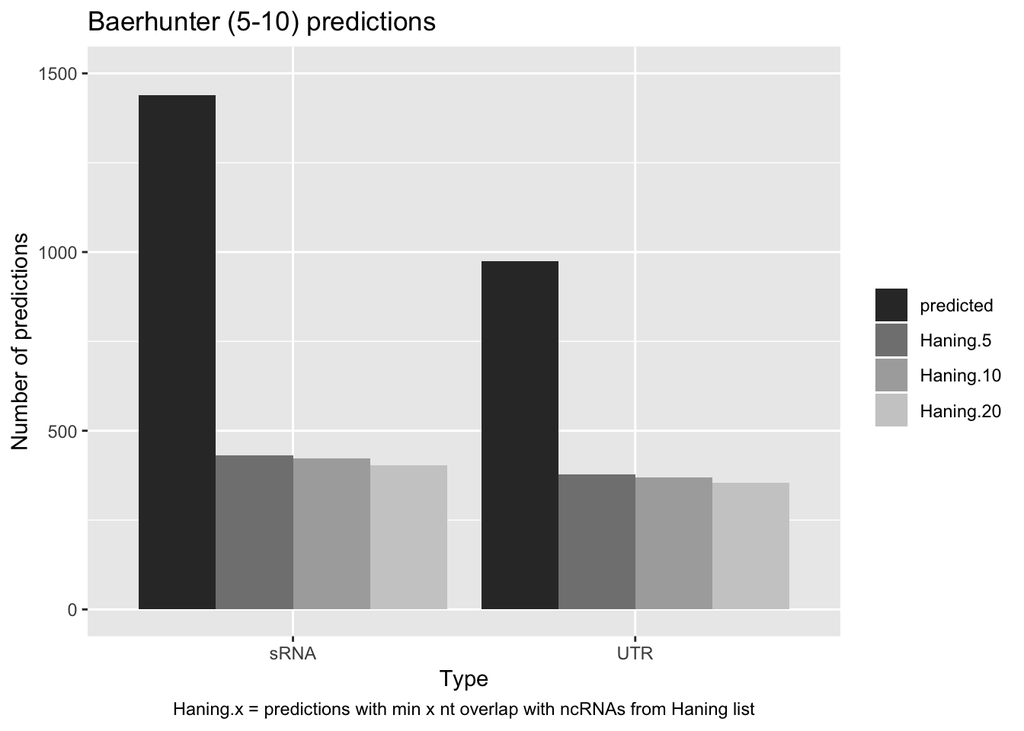

```r
# We will repeat this process several times so worth packaging in a function
compare_known_with_predicted <- function(annotation_file, known_RNA_file, minoverlap=1L) {
  # import the gff3 file using rtracklayer's import function
  annot <- import.gff3(annotation_file)

  # create subsets of the putative sRNAs and UTRs first
  pred.sRNA <- subset(annot, type == "putative_sRNA")
  pred.UTR <- subset(annot, type == "putative_UTR")
  num.pred.sRNA.plus <- length(ranges(subset(annot, (type == "putative_sRNA") & (strand == "+")) ) )
  num.pred.sRNA.minus <- length(ranges(subset(annot, (type == "putative_sRNA") & (strand == "-")) ) )
  num.pred.UTRs.plus <- length(ranges(subset(annot, (type == "putative_UTR") & (strand == "+")) ) )
  num.pred.UTRs.minus <- length(ranges(subset(annot, (type == "putative_UTR") & (strand == "-")) ) )

  # read in the data from Haning et al's supplementary tables
  known.ori <- read.delim(file=known_RNA_file, header=TRUE,   sep="\t",comment.char = "#")

  # some of the entries in the original table have no start or end - remove!
  dim(known.ori)
  known <- subset(known.ori, (!is.na(known.ori$Start) & !is.na(known.ori$End)))
  # check how many are left
  dim(known)
  known.all <- GRanges(seqnames="Chromosome",
                       ranges=IRanges(start=known[known[,"Start"] < known[,"End"],"Start"],
                                      end=known[known[,"Start"] < known[,"End"],"End"] ),
                       strand=rep("+", dim(known[known[,"Start"] < known[,"End"],])[1]))


  # we ignore the strand and count features on both strands
  sRNA.hits <- findOverlaps(known.all, pred.sRNA, type="any", minoverlap=minoverlap, ignore.strand=TRUE)
  UTR.hits <- findOverlaps(known.all, pred.UTR, type="any", minoverlap=minoverlap, ignore.strand=TRUE )

  #how many predicted hits  are confirmed?
  num_UTR_confirmed <- length(unique(subjectHits(UTR.hits)))
  num_sRNA_confirmed <- length(unique(subjectHits(sRNA.hits)))
  num_all_confirmed <- length(unique(c(subjectHits(UTR.hits), subjectHits(sRNA.hits))))

  num_UTR_confirmed
  num_sRNA_confirmed
  num_all_confirmed

  num_pred_UTR <- length(ranges(pred.UTR))
  num_pred_sRNA <- length(ranges(pred.sRNA))
  num_pred_UTR
  num_pred_sRNA

  res <- c(num_pred_UTR, num_pred_sRNA, num_UTR_confirmed, num_sRNA_confirmed)
  names(res) <- c('num_pred_UTR', 'num_pred_sRNA', 'num_UTR_confirmed', 'num_sRNA_confirmed')

  return(res)
}

# ****** CHECK BAERHUNTER RESULTS******* #
# Run the function to carry out the comparisons between confirmed RNAs and predicted ones and unconfirmed RNAs and predicted ones
res_5.10_1 <- compare_known_with_predicted(annotation_file="output/real_data/mtb_5_10.gff3", minoverlap=1L, known_RNA_file ="data/ALINA_Confirmed_sRNAs_MTB_Haning_2014_edited.csv")

res_5.10_5 <- compare_known_with_predicted(annotation_file="output/real_data/mtb_5_10.gff3", minoverlap=5L, known_RNA_file ="data/ALINA_Confirmed_sRNAs_MTB_Haning_2014_edited.csv")

res_5.10_10 <- compare_known_with_predicted(annotation_file="output/real_data/mtb_5_10.gff3", minoverlap=10L, known_RNA_file ="data/ALINA_Confirmed_sRNAs_MTB_Haning_2014_edited.csv")

res_5.10_20 <- compare_known_with_predicted(annotation_file="output/real_data/mtb_5_10.gff3", minoverlap=20L, known_RNA_file ="data/ALINA_Confirmed_sRNAs_MTB_Haning_2014_edited.csv")

res_5.10_50 <- compare_known_with_predicted(annotation_file="output/real_data/mtb_5_10.gff3", minoverlap=50L, known_RNA_file ="data/ALINA_Confirmed_sRNAs_MTB_Haning_2014_edited.csv")

# Comparing results to list of unconfirmed ncRNAs from Haning's paper
res_5.10_1_u <- compare_known_with_predicted(annotation_file="output/real_data/mtb_5_10.gff3", minoverlap=1L, known_RNA_file ="data/table_ncRNAs_Mtb_unconfirmed.txt")

res_5.10_5_u <- compare_known_with_predicted(annotation_file="output/real_data/mtb_5_10.gff3", minoverlap=5L, known_RNA_file ="data/table_ncRNAs_Mtb_unconfirmed.txt")

res_5.10_10_u <- compare_known_with_predicted(annotation_file="output/real_data/mtb_5_10.gff3", minoverlap=10L, known_RNA_file ="data/table_ncRNAs_Mtb_unconfirmed.txt")

res_5.10_20_u <- compare_known_with_predicted(annotation_file="output/real_data/mtb_5_10.gff3", minoverlap=20L, known_RNA_file ="data/table_ncRNAs_Mtb_unconfirmed.txt")

res_5.10_50_u <- compare_known_with_predicted(annotation_file="output/real_data/mtb_5_10.gff3", minoverlap=50L, known_RNA_file ="data/table_ncRNAs_Mtb_unconfirmed.txt")

# Plot the results as barplots
v.y  <- c(res_5.10_5[1], res_5.10_5[3]+res_5.10_5_u[3], res_5.10_10[3]+res_5.10_10_u[3], res_5.10_20[3]+res_5.10_20_u[3], res_5.10_5[2], res_5.10_5[4]+res_5.10_5_u[4], res_5.10_10[4]+res_5.10_10_u[4], res_5.10_20[4]+res_5.10_20_u[4])
v.labels <- rep(c("predicted", "Haning.5", "Haning.10", "Haning.20"), 2)
v.type <- c(rep("UTR", 4), rep("sRNA", 4))
df <- data.frame(cbind(v.labels, v.type, v.y))
colnames(df) <- c("labels", "type", "num_predictions")
#put the v.types factor in the right order in the plot
df$labels <- factor(df$labels, levels=c('predicted', 'Haning.5', 'Haning.10', 'Haning.20'))
# df$v.y is factor and needs to be numeric
p <- ggplot(data=df, aes(x=type, y=as.numeric(as.character(num_predictions)), fill=labels)) +
    geom_bar(stat="identity", position=position_dodge()) +
    scale_y_continuous(limits=c(0, 1500)) +
    xlab("Type") +
    ylab("Number of predictions") +
    labs(fill='') +
    scale_fill_grey() +
    labs(title="Baerhunter (5-10) predictions", caption="Haning.x = predictions with min x nt overlap with ncRNAs from Haning list") +
    theme(plot.caption = element_text(hjust=0.5))

p
```

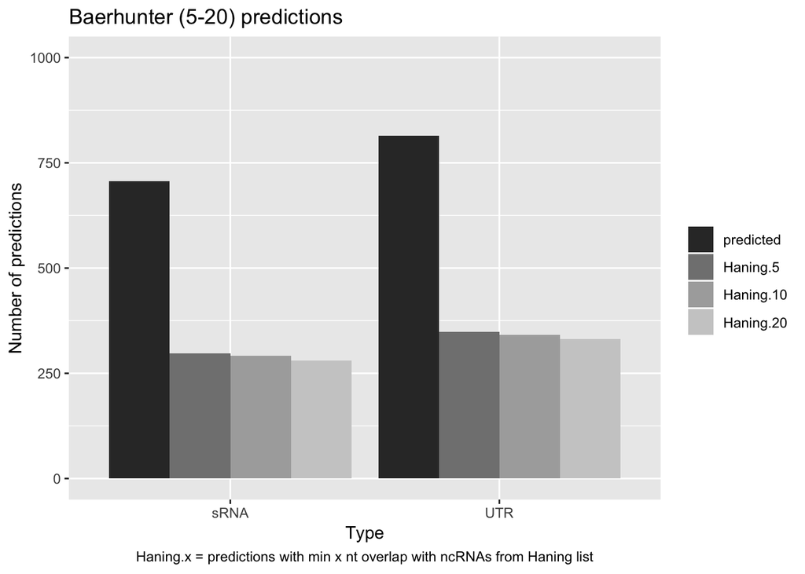

```r
# REPEAT for other cut-offs
# Cut-off 5-20
res_5.20_1 <- compare_known_with_predicted(annotation_file="output/real_data/mtb_5_20.gff3", minoverlap=1L, known_RNA_file ="data/ALINA_Confirmed_sRNAs_MTB_Haning_2014_edited.csv")

res_5.20_5 <- compare_known_with_predicted(annotation_file="output/real_data/mtb_5_20.gff3", minoverlap=5L, known_RNA_file ="data/ALINA_Confirmed_sRNAs_MTB_Haning_2014_edited.csv")

res_5.20_10 <- compare_known_with_predicted(annotation_file="output/real_data/mtb_5_20.gff3", minoverlap=10L, known_RNA_file ="data/ALINA_Confirmed_sRNAs_MTB_Haning_2014_edited.csv")

res_5.20_20 <- compare_known_with_predicted(annotation_file="output/real_data/mtb_5_20.gff3", minoverlap=20L, known_RNA_file ="data/ALINA_Confirmed_sRNAs_MTB_Haning_2014_edited.csv")

res_5.20_50 <- compare_known_with_predicted(annotation_file="output/real_data/mtb_5_20.gff3", minoverlap=50L, known_RNA_file ="data/ALINA_Confirmed_sRNAs_MTB_Haning_2014_edited.csv")

# Comparing results to list of unconfirmed ncRNAs from Haning's paper
res_5.20_1_u <- compare_known_with_predicted(annotation_file="output/real_data/mtb_5_20.gff3", minoverlap=1L, known_RNA_file ="data/table_ncRNAs_Mtb_unconfirmed.txt")

res_5.20_5_u <- compare_known_with_predicted(annotation_file="output/real_data/mtb_5_20.gff3", minoverlap=5L, known_RNA_file ="data/table_ncRNAs_Mtb_unconfirmed.txt")

res_5.20_10_u <- compare_known_with_predicted(annotation_file="output/real_data/mtb_5_20.gff3", minoverlap=10L, known_RNA_file ="data/table_ncRNAs_Mtb_unconfirmed.txt")

res_5.20_20_u <- compare_known_with_predicted(annotation_file="output/real_data/mtb_5_20.gff3", minoverlap=20L, known_RNA_file ="data/table_ncRNAs_Mtb_unconfirmed.txt")

res_5.20_50_u <- compare_known_with_predicted(annotation_file="output/real_data/mtb_5_20.gff3", minoverlap=50L, known_RNA_file ="data/table_ncRNAs_Mtb_unconfirmed.txt")

# Plot the results as barplots
v.y  <- c(res_5.20_5[1], res_5.20_5[3]+res_5.20_5_u[3], res_5.20_10[3]+res_5.20_10_u[3], res_5.20_20[3]+res_5.20_20_u[3], res_5.20_5[2], res_5.20_5[4]+res_5.20_5_u[4], res_5.20_10[4]+res_5.20_10_u[4], res_5.20_20[4]+res_5.20_20_u[4])
v.labels <- rep(c("predicted", "Haning.5", "Haning.10", "Haning.20"), 2)
v.type <- c(rep("UTR", 4), rep("sRNA", 4))
df <- data.frame(cbind(v.labels, v.type, v.y))
colnames(df) <- c("labels", "type", "num_predictions")
#put the v.types factor in the right order in the plot
df$labels <- factor(df$labels, levels=c('predicted', 'Haning.5', 'Haning.10', 'Haning.20'))
# df$v.y is factor and needs to be numeric
p <- ggplot(data=df, aes(x=type, y=as.numeric(as.character(num_predictions)), fill=labels)) +
    geom_bar(stat="identity", position=position_dodge()) +
    scale_y_continuous(limits=c(0, 1000)) +
    xlab("Type") +
    ylab("Number of predictions") +
    labs(fill='') +
    scale_fill_grey() +
    labs(title="Baerhunter (5-20) predictions", caption="Haning.x = predictions with min x nt overlap with ncRNAs from Haning list") +
    theme(plot.caption = element_text(hjust=0.5))

p
```

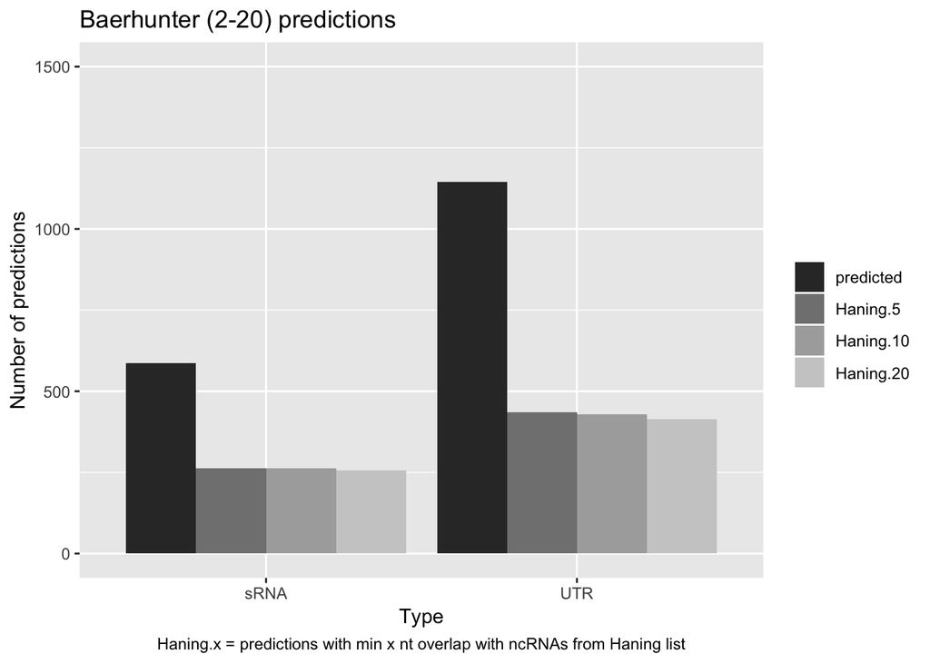

```r
# Cut-off 2-20
res_2.20_1 <- compare_known_with_predicted(annotation_file="output/real_data/mtb_2_20.gff3", minoverlap=1L, known_RNA_file ="data/ALINA_Confirmed_sRNAs_MTB_Haning_2014_edited.csv")

res_2.20_5 <- compare_known_with_predicted(annotation_file="output/real_data/mtb_2_20.gff3", minoverlap=5L, known_RNA_file ="data/ALINA_Confirmed_sRNAs_MTB_Haning_2014_edited.csv")

res_2.20_10 <- compare_known_with_predicted(annotation_file="output/real_data/mtb_2_20.gff3", minoverlap=10L, known_RNA_file ="data/ALINA_Confirmed_sRNAs_MTB_Haning_2014_edited.csv")

res_2.20_20 <- compare_known_with_predicted(annotation_file="output/real_data/mtb_2_20.gff3", minoverlap=20L, known_RNA_file ="data/ALINA_Confirmed_sRNAs_MTB_Haning_2014_edited.csv")

res_2.20_50 <- compare_known_with_predicted(annotation_file="output/real_data/mtb_2_20.gff3", minoverlap=50L, known_RNA_file ="data/ALINA_Confirmed_sRNAs_MTB_Haning_2014_edited.csv")

# Comparing results to list of unconfirmed ncRNAs from Haning's paper
res_2.20_1_u <- compare_known_with_predicted(annotation_file="output/real_data/mtb_2_20.gff3", minoverlap=1L, known_RNA_file ="data/table_ncRNAs_Mtb_unconfirmed.txt")

res_2.20_5_u <- compare_known_with_predicted(annotation_file="output/real_data/mtb_2_20.gff3", minoverlap=5L, known_RNA_file ="data/table_ncRNAs_Mtb_unconfirmed.txt")

res_2.20_10_u <- compare_known_with_predicted(annotation_file="output/real_data/mtb_2_20.gff3", minoverlap=10L, known_RNA_file ="data/table_ncRNAs_Mtb_unconfirmed.txt")

res_2.20_20_u <- compare_known_with_predicted(annotation_file="output/real_data/mtb_2_20.gff3", minoverlap=20L, known_RNA_file ="data/table_ncRNAs_Mtb_unconfirmed.txt")

res_2.20_50_u <- compare_known_with_predicted(annotation_file="output/real_data/mtb_2_20.gff3", minoverlap=50L, known_RNA_file ="data/table_ncRNAs_Mtb_unconfirmed.txt")

# Plot the results as barplots
v.y  <- c(res_2.20_5[1], res_2.20_5[3]+res_2.20_5_u[3], res_2.20_10[3]+res_2.20_10_u[3], res_2.20_20[3]+res_2.20_20_u[3], res_2.20_5[2], res_2.20_5[4]+res_2.20_5_u[4], res_2.20_10[4]+res_2.20_10_u[4], res_2.20_20[4]+res_2.20_20_u[4])
v.labels <- rep(c("predicted", "Haning.5", "Haning.10", "Haning.20"), 2)
v.type <- c(rep("UTR", 4), rep("sRNA", 4))
df <- data.frame(cbind(v.labels, v.type, v.y))
colnames(df) <- c("labels", "type", "num_predictions")
#put the v.types factor in the right order in the plot
df$labels <- factor(df$labels, levels=c('predicted', 'Haning.5', 'Haning.10', 'Haning.20'))
# df$v.y is factor and needs to be numeric
p <- ggplot(data=df, aes(x=type, y=as.numeric(as.character(num_predictions)), fill=labels)) +
    geom_bar(stat="identity", position=position_dodge()) +
    scale_y_continuous(limits=c(0, 1500)) +
    xlab("Type") +
    ylab("Number of predictions") +
    labs(fill='') +
    scale_fill_grey() +
    labs(title="Baerhunter (2-20) predictions", caption="Haning.x = predictions with min x nt overlap with ncRNAs from Haning list") +
    theme(plot.caption = element_text(hjust=0.5))
p
```

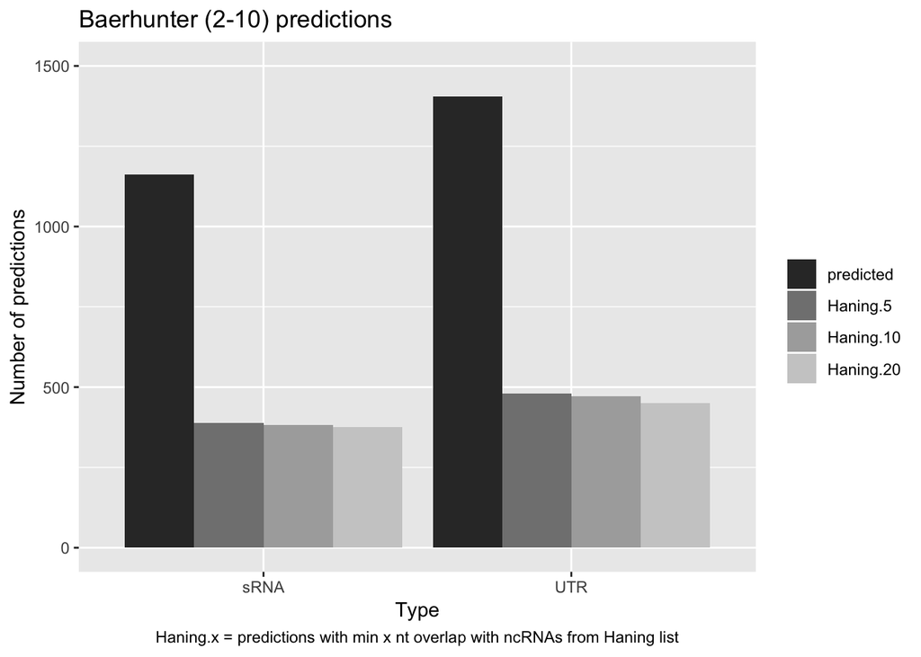

```r
# Cut-off 2-10
res_2.10_1 <- compare_known_with_predicted(annotation_file="output/real_data/mtb_2_10.gff3", minoverlap=1L, known_RNA_file ="data/ALINA_Confirmed_sRNAs_MTB_Haning_2014_edited.csv")

res_2.10_5 <- compare_known_with_predicted(annotation_file="output/real_data/mtb_2_10.gff3", minoverlap=5L, known_RNA_file ="data/ALINA_Confirmed_sRNAs_MTB_Haning_2014_edited.csv")

res_2.10_10 <- compare_known_with_predicted(annotation_file="output/real_data/mtb_2_10.gff3", minoverlap=10L, known_RNA_file ="data/ALINA_Confirmed_sRNAs_MTB_Haning_2014_edited.csv")

res_2.10_20 <- compare_known_with_predicted(annotation_file="output/real_data/mtb_2_10.gff3", minoverlap=20L, known_RNA_file ="data/ALINA_Confirmed_sRNAs_MTB_Haning_2014_edited.csv")

res_2.10_50 <- compare_known_with_predicted(annotation_file="output/real_data/mtb_2_10.gff3", minoverlap=50L, known_RNA_file ="data/ALINA_Confirmed_sRNAs_MTB_Haning_2014_edited.csv")

# Comparing results to list of unconfirmed ncRNAs from Haning's paper
res_2.10_1_u <- compare_known_with_predicted(annotation_file="output/real_data/mtb_2_10.gff3", minoverlap=1L, known_RNA_file ="data/table_ncRNAs_Mtb_unconfirmed.txt")

res_2.10_5_u <- compare_known_with_predicted(annotation_file="output/real_data/mtb_2_10.gff3", minoverlap=5L, known_RNA_file ="data/table_ncRNAs_Mtb_unconfirmed.txt")

res_2.10_10_u <- compare_known_with_predicted(annotation_file="output/real_data/mtb_2_10.gff3", minoverlap=10L, known_RNA_file ="data/table_ncRNAs_Mtb_unconfirmed.txt")

res_2.10_20_u <- compare_known_with_predicted(annotation_file="output/real_data/mtb_2_10.gff3", minoverlap=20L, known_RNA_file ="data/table_ncRNAs_Mtb_unconfirmed.txt")

res_2.10_50_u <- compare_known_with_predicted(annotation_file="output/real_data/mtb_2_10.gff3", minoverlap=50L, known_RNA_file ="data/table_ncRNAs_Mtb_unconfirmed.txt")

# Plot the results as barplots
v.y  <- c(res_2.10_5[1], res_2.10_5[3]+res_2.10_5_u[3], res_2.10_10[3]+res_2.10_10_u[3], res_2.10_20[3]+res_2.10_20_u[3], res_2.10_5[2], res_2.10_5[4]+res_2.10_5_u[4], res_2.10_10[4]+res_2.10_10_u[4], res_2.10_20[4]+res_2.10_20_u[4])
v.labels <- rep(c("predicted", "Haning.5", "Haning.10", "Haning.20"), 2)
v.type <- c(rep("UTR", 4), rep("sRNA", 4))
df <- data.frame(cbind(v.labels, v.type, v.y))
colnames(df) <- c("labels", "type", "num_predictions")
#put the v.types factor in the right order in the plot
df$labels <- factor(df$labels, levels=c('predicted', 'Haning.5', 'Haning.10', 'Haning.20'))
# df$v.y is factor and needs to be numeric
p <- ggplot(data=df, aes(x=type, y=as.numeric(as.character(num_predictions)), fill=labels)) +
    geom_bar(stat="identity", position=position_dodge()) +
    scale_y_continuous(limits=c(0, 1500)) +
    xlab("Type") +
    ylab("Number of predictions") +
    labs(fill='') +
    scale_fill_grey() +
    labs(title="Baerhunter (2-10) predictions", caption="Haning.x = predictions with min x nt overlap with ncRNAs from Haning list") +
    theme(plot.caption = element_text(hjust=0.5))

p
```

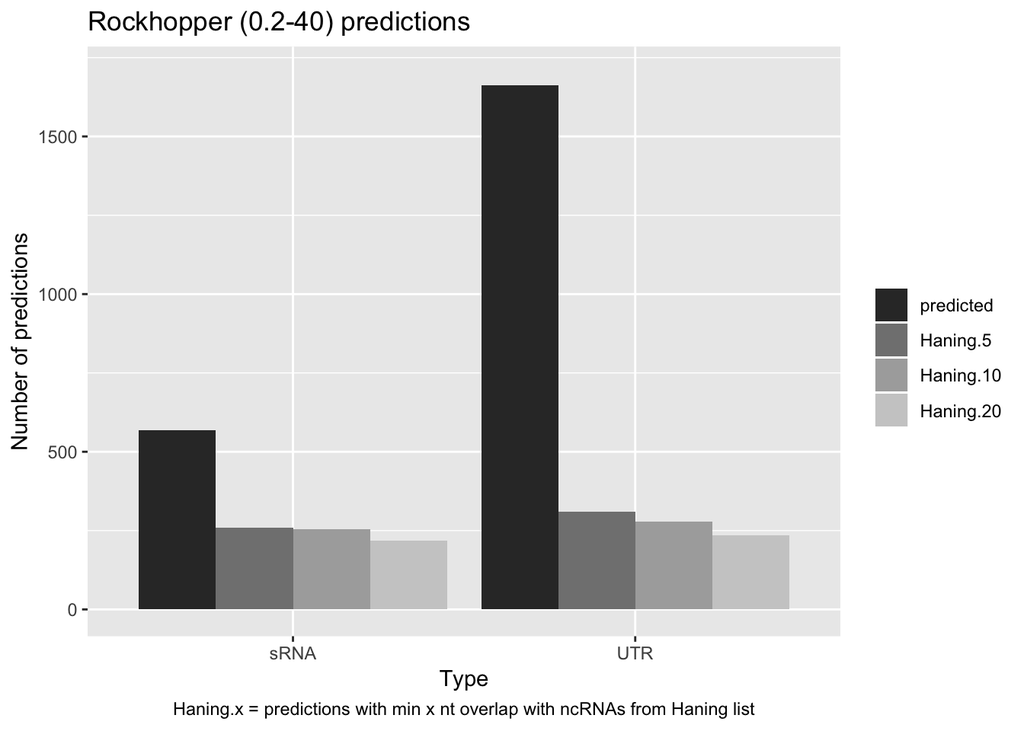

```r
# ***** CHECK ROCKHOPPER RESULTS ***** #
#Run the functions to carry out the comparisons between confirmed RNAs and predicted ones and unconfirmed RNAs and predicted ones (by Rockhopper)
res_0.2_40_1 <- compare_known_with_predicted(annotation_file="output/real_data/rockhopper_bam_0.2_40_output/NC_999999.gff3", minoverlap=1L, known_RNA_file ="data/ALINA_Confirmed_sRNAs_MTB_Haning_2014_edited.csv")

res_0.2_40_5 <- compare_known_with_predicted(annotation_file="output/real_data/rockhopper_bam_0.2_40_output/NC_999999.gff3", minoverlap=5L, known_RNA_file ="data/ALINA_Confirmed_sRNAs_MTB_Haning_2014_edited.csv")

res_0.2_40_10 <- compare_known_with_predicted(annotation_file="output/real_data/rockhopper_bam_0.2_40_output/NC_999999.gff3", minoverlap=10L, known_RNA_file ="data/ALINA_Confirmed_sRNAs_MTB_Haning_2014_edited.csv")

res_0.2_40_20 <- compare_known_with_predicted(annotation_file="output/real_data/rockhopper_bam_0.2_40_output/NC_999999.gff3", minoverlap=20L, known_RNA_file ="data/ALINA_Confirmed_sRNAs_MTB_Haning_2014_edited.csv")

res_0.2_40_50 <- compare_known_with_predicted(annotation_file="output/real_data/rockhopper_bam_0.2_40_output/NC_999999.gff3", minoverlap=50L, known_RNA_file ="data/ALINA_Confirmed_sRNAs_MTB_Haning_2014_edited.csv")

#comparing to unconfirmed ones
res_0.2_40_1_u <- compare_known_with_predicted(annotation_file="output/real_data/rockhopper_bam_0.2_40_output/NC_999999.gff3", minoverlap=1L, known_RNA_file ="data/table_ncRNAs_Mtb_unconfirmed.txt")

res_0.2_40_5_u<- compare_known_with_predicted(annotation_file="output/real_data/rockhopper_bam_0.2_40_output/NC_999999.gff3", minoverlap=5L, known_RNA_file ="data/table_ncRNAs_Mtb_unconfirmed.txt")

res_0.2_40_10_u <- compare_known_with_predicted(annotation_file="output/real_data/rockhopper_bam_0.2_40_output/NC_999999.gff3", minoverlap=10L, known_RNA_file ="data/table_ncRNAs_Mtb_unconfirmed.txt")

res_0.2_40_20_u <- compare_known_with_predicted(annotation_file="output/real_data/rockhopper_bam_0.2_40_output/NC_999999.gff3", minoverlap=20L, known_RNA_file ="data/table_ncRNAs_Mtb_unconfirmed.txt")

res_0.2_40_50_u <- compare_known_with_predicted(annotation_file="output/real_data/rockhopper_bam_0.2_40_output/NC_999999.gff3", minoverlap=50L, known_RNA_file ="data/table_ncRNAs_Mtb_unconfirmed.txt")


#plot the results as barplots
v.y  <- c(res_0.2_40_5[1], res_0.2_40_5[3]+res_0.2_40_5_u[3], res_0.2_40_10[3]+res_0.2_40_10_u[3], res_0.2_40_20[3]+res_0.2_40_20_u[3], res_0.2_40_5[2], res_0.2_40_5[4]+res_0.2_40_5_u[4], res_0.2_40_10[4]+res_0.2_40_10_u[4], res_0.2_40_20[4]+res_0.2_40_20_u[4])
v.labels <- rep(c("predicted", "Haning.5", "Haning.10", "Haning.20"), 2)
v.type <- c(rep("UTR", 4), rep("sRNA", 4))
df.rh <- data.frame(cbind(v.labels, v.type, v.y))
colnames(df.rh) <- c("labels", "type", "num_predictions")
#put the v.types factor in the right order in the plot
df.rh$labels <- factor(df.rh$labels, levels=c('predicted', 'Haning.5', 'Haning.10', 'Haning.20'))
# df$v.y is factor and needs to be numeric
p <- ggplot(data=df.rh, aes(x=type, y=as.numeric(as.character(num_predictions)), fill=labels)) +
    geom_bar(stat="identity", position=position_dodge()) +
    scale_y_continuous(limits=c(0, 1700)) +
    xlab("Type") +
    ylab("Number of predictions") +
    labs(fill='') +
    scale_fill_grey() +
    labs(title="Rockhopper (0.2-40) predictions", caption="Haning.x = predictions with min x nt overlap with ncRNAs from Haning list") +
    theme(plot.caption = element_text(hjust=0.5))

p
```

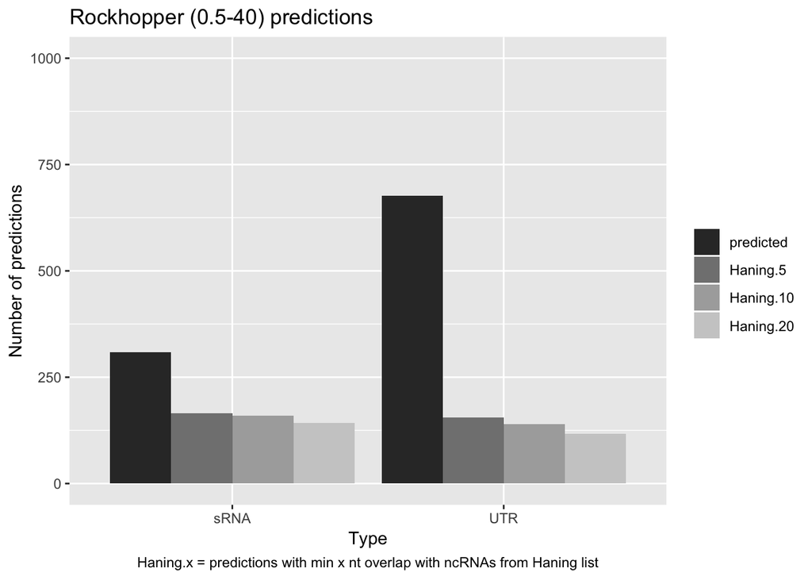

```r
## REPEAT with Rockhopper 0.5-40
# Rockhopper 0.5-40
res_0.5_40_1 <- compare_known_with_predicted(annotation_file="output/real_data/rockhopper_bam_0.5_40_output/NC_999999.gff3", minoverlap=1L, known_RNA_file ="data/ALINA_Confirmed_sRNAs_MTB_Haning_2014_edited.csv")

res_0.5_40_5 <- compare_known_with_predicted(annotation_file="output/real_data/rockhopper_bam_0.5_40_output/NC_999999.gff3", minoverlap=5L, known_RNA_file ="data/ALINA_Confirmed_sRNAs_MTB_Haning_2014_edited.csv")

res_0.5_40_10 <- compare_known_with_predicted(annotation_file="output/real_data/rockhopper_bam_0.5_40_output/NC_999999.gff3", minoverlap=10L, known_RNA_file ="data/ALINA_Confirmed_sRNAs_MTB_Haning_2014_edited.csv")

res_0.5_40_20 <- compare_known_with_predicted(annotation_file="output/real_data/rockhopper_bam_0.5_40_output/NC_999999.gff3", minoverlap=20L, known_RNA_file ="data/ALINA_Confirmed_sRNAs_MTB_Haning_2014_edited.csv")

res_0.5_40_50 <- compare_known_with_predicted(annotation_file="output/real_data/rockhopper_bam_0.5_40_output/NC_999999.gff3", minoverlap=50L, known_RNA_file ="data/ALINA_Confirmed_sRNAs_MTB_Haning_2014_edited.csv")

#comparing to unconfirmed ones
res_0.5_40_1_u <- compare_known_with_predicted(annotation_file="output/real_data/rockhopper_bam_0.5_40_output/NC_999999.gff3", minoverlap=1L, known_RNA_file ="data/table_ncRNAs_Mtb_unconfirmed.txt")

res_0.5_40_5_u<- compare_known_with_predicted(annotation_file="output/real_data/rockhopper_bam_0.5_40_output/NC_999999.gff3", minoverlap=5L, known_RNA_file ="data/table_ncRNAs_Mtb_unconfirmed.txt")

res_0.5_40_10_u <- compare_known_with_predicted(annotation_file="output/real_data/rockhopper_bam_0.5_40_output/NC_999999.gff3", minoverlap=10L, known_RNA_file ="data/table_ncRNAs_Mtb_unconfirmed.txt")

res_0.5_40_20_u <- compare_known_with_predicted(annotation_file="output/real_data/rockhopper_bam_0.5_40_output/NC_999999.gff3", minoverlap=20L, known_RNA_file ="data/table_ncRNAs_Mtb_unconfirmed.txt")

res_0.5_40_50_u <- compare_known_with_predicted(annotation_file="output/real_data/rockhopper_bam_0.5_40_output/NC_999999.gff3", minoverlap=50L, known_RNA_file ="data/table_ncRNAs_Mtb_unconfirmed.txt")


#plot the results as barplots
v.y  <- c(res_0.5_40_5[1], res_0.5_40_5[3]+res_0.5_40_5_u[3], res_0.5_40_10[3]+res_0.5_40_10_u[3], res_0.5_40_20[3]+res_0.5_40_20_u[3], res_0.5_40_5[2], res_0.5_40_5[4]+res_0.5_40_5_u[4], res_0.5_40_10[4]+res_0.5_40_10_u[4], res_0.5_40_20[4]+res_0.5_40_20_u[4])
v.labels <- rep(c("predicted", "Haning.5", "Haning.10", "Haning.20"), 2)
v.type <- c(rep("UTR", 4), rep("sRNA", 4))
df.rh <- data.frame(cbind(v.labels, v.type, v.y))
colnames(df.rh) <- c("labels", "type", "num_predictions")
#put the v.types factor in the right order in the plot
df.rh$labels <- factor(df.rh$labels, levels=c('predicted', 'Haning.5', 'Haning.10', 'Haning.20'))
# df$v.y is factor and needs to be numeric
p <- ggplot(data=df.rh, aes(x=type, y=as.numeric(as.character(num_predictions)), fill=labels)) +
    geom_bar(stat="identity", position=position_dodge()) +
    scale_y_continuous(limits=c(0, 1000)) +
    xlab("Type") +
    ylab("Number of predictions") +
    labs(fill='') +
    scale_fill_grey() +
    labs(title="Rockhopper (0.5-40) predictions", caption="Haning.x = predictions with min x nt overlap with ncRNAs from Haning list") +
    theme(plot.caption = element_text(hjust=0.5))

p
```

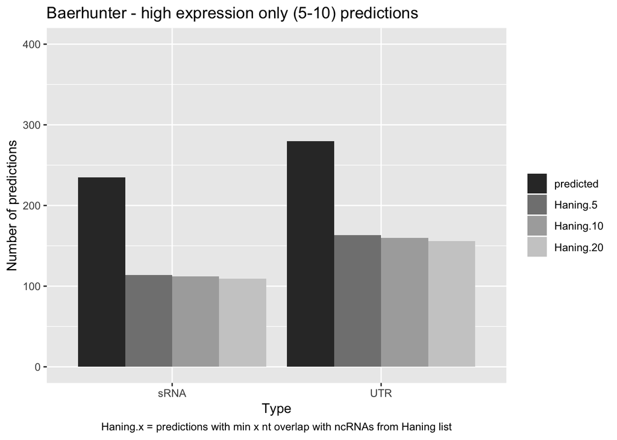

```r
## END REPEAT

# Check predictions using high-expression transcripts only
hres_5.10_1 <- compare_known_with_predicted(annotation_file="output/real_data/filtered_high_expression_sRNA_mtb_5_10.gff3", minoverlap=1L, known_RNA_file ="data/ALINA_Confirmed_sRNAs_MTB_Haning_2014_edited.csv")

hres_5.10_5 <- compare_known_with_predicted(annotation_file="output/real_data/filtered_high_expression_sRNA_mtb_5_10.gff3", minoverlap=5L, known_RNA_file ="data/ALINA_Confirmed_sRNAs_MTB_Haning_2014_edited.csv")

hres_5.10_10 <- compare_known_with_predicted(annotation_file="output/real_data/filtered_high_expression_sRNA_mtb_5_10.gff3", minoverlap=10L, known_RNA_file ="data/ALINA_Confirmed_sRNAs_MTB_Haning_2014_edited.csv")

hres_5.10_20 <- compare_known_with_predicted(annotation_file="output/real_data/filtered_high_expression_sRNA_mtb_5_10.gff3", minoverlap=20L, known_RNA_file ="data/ALINA_Confirmed_sRNAs_MTB_Haning_2014_edited.csv")

#comparing to unconfirmed ones
hres_5.10_1_u <- compare_known_with_predicted(annotation_file="output/real_data/filtered_high_expression_sRNA_mtb_5_10.gff3", minoverlap=1L, known_RNA_file ="data/table_ncRNAs_Mtb_unconfirmed.txt")

hres_5.10_5_u <- compare_known_with_predicted(annotation_file="output/real_data/filtered_high_expression_sRNA_mtb_5_10.gff3", minoverlap=5L, known_RNA_file ="data/table_ncRNAs_Mtb_unconfirmed.txt")

hres_5.10_10_u <- compare_known_with_predicted(annotation_file="output/real_data/filtered_high_expression_sRNA_mtb_5_10.gff3", minoverlap=10L, known_RNA_file ="data/table_ncRNAs_Mtb_unconfirmed.txt")

hres_5.10_20_u <- compare_known_with_predicted(annotation_file="output/real_data/filtered_high_expression_sRNA_mtb_5_10.gff3", minoverlap=20L, known_RNA_file ="data/table_ncRNAs_Mtb_unconfirmed.txt")

#plot the results as barplots
v.y  <- c(hres_5.10_5[1], hres_5.10_5[3]+hres_5.10_5_u[3], hres_5.10_10[3]+hres_5.10_10_u[3], hres_5.10_20[3]+hres_5.10_20_u[3], hres_5.10_5[2], hres_5.10_5[4]+hres_5.10_5_u[4], hres_5.10_10[4]+hres_5.10_10_u[4], hres_5.10_20[4]+hres_5.10_20_u[4])
v.labels <- rep(c("predicted", "Haning.5", "Haning.10", "Haning.20"), 2)
v.type <- c(rep("UTR", 4), rep("sRNA", 4))
df <- data.frame(cbind(v.labels, v.type, v.y))
colnames(df) <- c("labels", "type", "num_predictions")
#put the v.types factor in the right order in the plot
df$labels <- factor(df$labels, levels=c('predicted', 'Haning.5', 'Haning.10', 'Haning.20'))
# df$v.y is factor and needs to be numeric
p <- ggplot(data=df, aes(x=type, y=as.numeric(as.character(num_predictions)), fill=labels)) +
    geom_bar(stat="identity", position=position_dodge()) +
    scale_y_continuous(limits=c(0, 400)) +
    xlab("Type") +
    ylab("Number of predictions") +
    labs(fill='') +
    scale_fill_grey() +
    labs(title="Baerhunter - high expression only (5-10) predictions", caption="Haning.x = predictions with min x nt overlap with ncRNAs from Haning list") +
    theme(plot.caption = element_text(hjust=0.5))

p
```

```r
# print out a table with a summary of the results
create_Haning_results_vector <- function(v1, v1.u, v5, v5.u, v10, v10.u, v20, v20.u)  {
  res.v <- c(v1[1], v1[3]+v1.u[3], v5[3]+v5.u[3], v10[3]+v10.u[3], v20[3]+v20.u[3],
             v1[2], v1[4]+v1.u[4], v5[4]+v5.u[4], v10[4]+v10.u[4], v20[4]+v20.u[4])
  names(res.v) <- c("num_pred_UTR", "UTR_Haning.1", "UTR_Haning.5", "UTR_Haning.10", "UTR_Haning.20", "num_pred_sRNA", "sRNA_Haning.1", "sRNA_Haning.5", "sRNA_Haning.10", "sRNA_Haning.20")
  return(res.v)
}

v.5_10 <- create_Haning_results_vector(res_5.10_1, res_5.10_1_u, res_5.10_5, res_5.10_5_u, res_5.10_10, res_5.10_10_u, res_5.10_20, res_5.10_20_u)

v.h.5_10 <- create_Haning_results_vector(hres_5.10_1, hres_5.10_1_u, hres_5.10_5, hres_5.10_5_u, hres_5.10_10, hres_5.10_10_u, hres_5.10_20, hres_5.10_20_u)

v.5_20 <- create_Haning_results_vector(res_5.20_1, res_5.20_1_u, res_5.20_5, res_5.20_5_u, res_5.20_10, res_5.20_10_u, res_5.20_20, res_5.20_20_u)

v.2_10 <- create_Haning_results_vector(res_2.10_1, res_2.10_1_u, res_2.10_5, res_2.10_5_u, res_2.10_10, res_2.10_10_u, res_2.10_20, res_2.10_20_u)

v.2_20 <- create_Haning_results_vector(res_2.20_1, res_2.20_1_u, res_2.20_5, res_2.20_5_u, res_2.20_10, res_2.20_10_u, res_2.20_20, res_2.20_20_u)

v.rh.02.40 <- create_Haning_results_vector(res_0.2_40_1, res_0.2_40_1_u, res_0.2_40_5, res_0.2_40_5_u, res_0.2_40_10, res_0.2_40_10_u, res_0.2_40_20, res_0.2_40_20_u)

v.rh.05.40 <- create_Haning_results_vector(res_0.5_40_1, res_0.5_40_1_u, res_0.5_40_5, res_0.5_40_5_u, res_0.5_40_10, res_0.5_40_10_u, res_0.5_40_20, res_0.5_40_20_u)

m.Haning.res <- rbind(v.5_10, v.5_20, v.2_10, v.2_20, v.h.5_10, v.rh.02.40, v.rh.05.40)
colnames(m.Haning.res) <- c("num_pred_UTR", "UTR_Haning.1", "UTR_Haning.5", "UTR_Haning.10", "UTR_Haning.20", "num_pred_sRNA", "sRNA_Haning.1", "sRNA_Haning.5", "sRNA_Haning.10", "sRNA_Haning.20")
rownames(m.Haning.res) <- c("bh_5-10", "bh_5-20", "bh_2-10", "bh_2-20", "bh_he_5-10", "rh_0.2-40", "rh_0.5-40")

# Print out in a table the results of predicting sRNAs and UTRs and how they match the Haning tables of ncRNAs
m.Haning.res
```

```
##            num_pred_UTR UTR_Haning.1 UTR_Haning.5 UTR_Haning.10
## bh_5-10             975          383          377           369
## bh_5-20             815          354          349           342
## bh_2-10            1405          488          480           471
## bh_2-20            1144          445          435           428
## bh_he_5-10          280          164          163           160
## rh_0.2-40          1662          332          309           279
## rh_0.5-40           676          164          156           140
##            UTR_Haning.20 num_pred_sRNA sRNA_Haning.1 sRNA_Haning.5
## bh_5-10              354          1439           440           432
## bh_5-20              331           706           301           298
## bh_2-10              451          1163           398           388
## bh_2-20              413           586           268           263
## bh_he_5-10           156           235           116           114
## rh_0.2-40            234           568           268           259
## rh_0.5-40            117           309           167           165
##            sRNA_Haning.10 sRNA_Haning.20
## bh_5-10               422            404
## bh_5-20               292            281
## bh_2-10               383            375
## bh_2-20               263            256
## bh_he_5-10            112            109
## rh_0.2-40             254            219
## rh_0.5-40             160            142
```

## Overlap of predicted ncRNAs with TSS data

```r
tss.1 <- read.delim(file="data/Cortes_TSS_mmc2_1F.txt", header=TRUE,   sep="\t",comment.char = "#")
tss.2 <- read.delim(file="data/Cortes_TSS_mmc6_6E_starved.txt",header=TRUE,   sep="\t",comment.char = "#" )

tss.1f <- subset(tss.1, Strand == "F")
length(tss.1f$Genome.position)
```

```
## [1] 2109
```

```r
tss.1r <- subset(tss.1, Strand == "R")
length(tss.1r$Genome.position)
```

```
## [1] 2055
```

```r
tss.2f <- subset(tss.2, Strand == "F")
length(tss.2f$Genome.position)
```

```
## [1] 2072
```

```r
tss.2r <- subset(tss.2, Strand == "R")
length(tss.2r$Genome.position)
```

```
## [1] 2061
```

```r
#first create a set from the union of the two forward sets and then a set from the union of the two reverse sets
tss.f <- sort(union(tss.1f$Genome.position,tss.2f$Genome.position))
length(tss.f)
```

```
## [1] 2829
```

```r
tss.r <- sort(union(tss.1r$Genome.position, tss.2r$Genome.position))
length(tss.r)
```

```
## [1] 2825
```

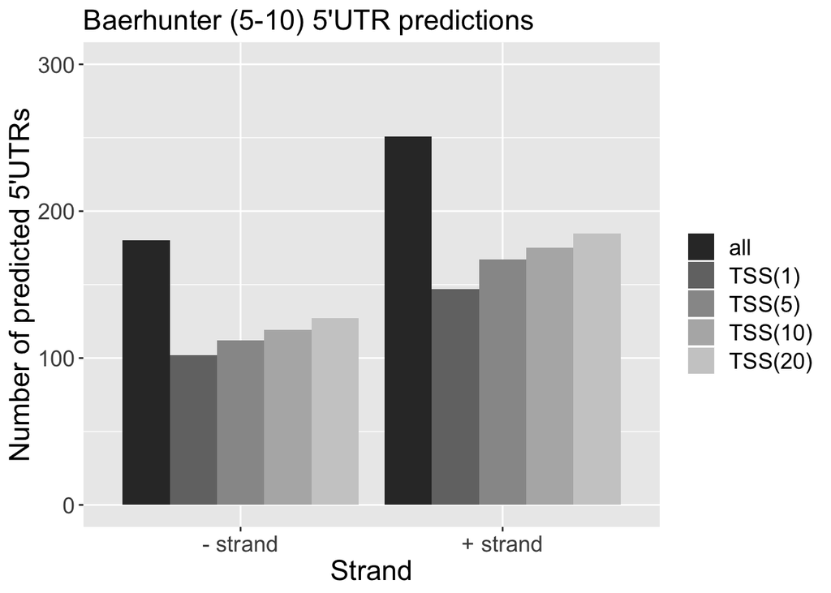

```r
#then create a GRanges object with 1nt ranges from the TSS positions
tss.f.gr <- GRanges(seqnames="Chromosome",  ranges=IRanges(start=tss.f, end = tss.f), strand=rep("+", length(tss.f)))
tss.r.gr <- GRanges(seqnames="Chromosome",  ranges=IRanges(start=tss.r, end = tss.r), strand=rep("-", length(tss.r)))
tss.gr <- c(tss.f.gr, tss.r.gr)


#finally, find the overlap between our predicted sRNA and UTRs and the TSS positions
#we will repeat this a few times so wrap it up in a function
compare_TSS_with_predicted <- function(annotation_file, tss.gr, maxgap=-1L) {

  #vector to hold the results
  res <- c()

   #import the gff3 file using rtracklayer's import function
  annot <- import.gff3(annotation_file)

  #create subsets of the putative sRNAs and UTRs first
  pred.sRNA.plus <- subset(annot, (type == "putative_sRNA") & (strand == "+"))
  num.pred.sRNA.plus <- length(ranges(pred.sRNA.plus))
  pred.sRNA.minus <- subset(annot, (type == "putative_sRNA") & (strand == "-"))
  num.pred.sRNA.minus <- length(ranges(pred.sRNA.minus))

  #NOTE: Only 5' UTRs would have experimental support!!
  #Hence, we need to isolate 5' UTRs ONLY from the annotation file. We will demand
  #that the end of the UTR is immediately followed by the start of a CDS on the same strand
  CDS.plus <- subset(annot, (type == "CDS") & (strand == "+"))
  pred.UTR.plus <- subset(annot, (type == "putative_UTR") & (strand == "+"))
  adj.pairs <- findOverlapPairs(CDS.plus, pred.UTR.plus, maxgap=1L)
  #the following extracts the pred.UTR.plus that satisfy the adjacency condition
  tmp.pred.5pUTR.plus <- second(subset(adj.pairs, start(first) == end(second) + 1L))
  #We also need to exclude 5' UTRs that are within operons as we often cannot tell whether they belong to the upstream or downstream gene and there is usually no TSS associated with them
  #cross the 5p UTRs with the CDS again:
  adj.pairs <- findOverlapPairs(CDS.plus, tmp.pred.5pUTR.plus, maxgap=1L)
  #and select the ones that are not 3' to any CDS
  rem.UTR <- second(subset(adj.pairs, start(second) == end(first) + 1L))
  pred.5pUTR.plus <- second(adj.pairs)[!(second(adj.pairs) %in% rem.UTR),]
  num.pred.UTR.plus <- length(ranges(pred.UTR.plus))
  num.pred.5pUTR.plus <- length(ranges(pred.5pUTR.plus))

  CDS.minus <- subset(annot, (type == "CDS") & (strand == "-"))
  pred.UTR.minus <- subset(annot, (type == "putative_UTR") & (strand == "-"))
  adj.pairs <- findOverlapPairs(CDS.minus, pred.UTR.minus, maxgap=1L)
  #the following extracts the pred.UTR.minus that satisfy the adjacency condition
  tmp.pred.5pUTR.minus <- second(subset(adj.pairs, start(second) == end(first) + 1L))
  #We also need to exclude 5' UTRs that are within operons as we cannot tell whether they belong to the upstream or downstream gene and there is usually no TSS associated with them
  #cross the 5p UTRs with the CDS again:
  adj.pairs <- findOverlapPairs(CDS.minus, tmp.pred.5pUTR.minus, maxgap=1L)
  #and select the ones that are not 3' to any CDS
  rem.UTR <- second(subset(adj.pairs, end(second) == start(first) - 1L))
  pred.5pUTR.minus <- second(adj.pairs)[!(second(adj.pairs) %in% rem.UTR),]
  num.pred.UTR.minus <- length(ranges(pred.UTR.minus))
  num.pred.5pUTR.minus <- length(ranges(pred.5pUTR.minus))

  # If type is "start" the intervals are required to have matching starts
  # - the maxgap parameter then means the maximum difference allowed in the starts
  hits_tss_pred.sRNA.plus <- findOverlaps(tss.gr, pred.sRNA.plus, type="start", maxgap=maxgap)
  hits_tss_pred.sRNA.minus <- findOverlaps(tss.gr, pred.sRNA.minus, type="end", maxgap=maxgap)
  hits_tss_pred.UTR.plus <- findOverlaps(tss.gr, pred.5pUTR.plus, type="start", maxgap=maxgap)
  hits_tss_pred.UTR.minus <- findOverlaps(tss.gr, pred.5pUTR.minus, type="end", maxgap=maxgap)

  #check which UTRs and sRNAs have no TSS
  pred.5pUTR.plus %outside% tss.gr
  pred.sRNA.plus %outside% tss.gr

   settings <- paste0(annotation_file, ":", maxgap)
  h <- c(
         "predicted sRNAs(+)",
         "predicted sRNAs(-)",
         "predicted UTRs(+)",
         "predicted UTRs(-)",
         "predicted 5p UTRs(+)",
         "predicted 5p UTRs(-)",
         "predicted sRNA(+) overlapping TSS",
         "predicted sRNA(-) overlapping TSS",
         "predicted 5p UTRs(+) overlapping TSS",
         "predicted 5p UTRs(-) overlapping TSS"
  )


   #add to vector so can plot later
  res <- c(num.pred.sRNA.plus, num.pred.sRNA.minus, num.pred.UTR.plus, num.pred.UTR.minus, num.pred.5pUTR.plus, num.pred.5pUTR.minus, length(unique(subjectHits(hits_tss_pred.sRNA.plus))), length(unique(subjectHits(hits_tss_pred.sRNA.minus))), length(unique(subjectHits(hits_tss_pred.UTR.plus))), length(unique(subjectHits(hits_tss_pred.UTR.minus)))
  )
  names(res) <- c(names(res), h)

  return(res)
}



# Check baerhunter results against known TSS #

tss_5.10_1 <- compare_TSS_with_predicted("output/real_data/mtb_5_10.gff3", tss.gr, maxgap=1L)

tss_5.10_5 <- compare_TSS_with_predicted("output/real_data/mtb_5_10.gff3", tss.gr, maxgap=5L)

tss_5.10_10 <- compare_TSS_with_predicted("output/real_data/mtb_5_10.gff3", tss.gr, maxgap=10L)

tss_5.10_20 <- compare_TSS_with_predicted("output/real_data/mtb_5_10.gff3", tss.gr, maxgap=20L)


# check also predictions for highly expressed transcripts only
tss_high5.10_1 <- compare_TSS_with_predicted("output/real_data/filtered_high_expression_sRNA_mtb_5_10.gff3", tss.gr, maxgap=1L)

tss_high5.10_5 <- compare_TSS_with_predicted("output/real_data/filtered_high_expression_sRNA_mtb_5_10.gff3", tss.gr, maxgap=5L)

tss_high5.10_10 <- compare_TSS_with_predicted("output/real_data/filtered_high_expression_sRNA_mtb_5_10.gff3", tss.gr, maxgap=10L)

tss_high5.10_20 <- compare_TSS_with_predicted("output/real_data/filtered_high_expression_sRNA_mtb_5_10.gff3", tss.gr, maxgap=20L)


# REPEAT WITH OTHER CUT-OFFS
tss_5.20_1 <- compare_TSS_with_predicted("output/real_data/mtb_5_20.gff3", tss.gr, maxgap=1L)

tss_5.20_5 <- compare_TSS_with_predicted("output/real_data/mtb_5_20.gff3", tss.gr, maxgap=5L)

tss_5.20_10 <- compare_TSS_with_predicted("output/real_data/mtb_5_20.gff3", tss.gr, maxgap=10L)

tss_5.20_20 <- compare_TSS_with_predicted("output/real_data/mtb_5_20.gff3", tss.gr, maxgap=20L)

tss_2.10_1 <- compare_TSS_with_predicted("output/real_data/mtb_2_10.gff3", tss.gr, maxgap=1L)

tss_2.10_5 <- compare_TSS_with_predicted("output/real_data/mtb_2_10.gff3", tss.gr, maxgap=5L)

tss_2.10_10 <- compare_TSS_with_predicted("output/real_data/mtb_2_10.gff3", tss.gr, maxgap=10L)

tss_2.10_20 <- compare_TSS_with_predicted("output/real_data/mtb_2_10.gff3", tss.gr, maxgap=20L)

tss_2.20_1 <- compare_TSS_with_predicted("output/real_data/mtb_2_20.gff3", tss.gr, maxgap=1L)

tss_2.20_5 <- compare_TSS_with_predicted("output/real_data/mtb_2_20.gff3", tss.gr, maxgap=5L)

tss_2.20_10 <- compare_TSS_with_predicted("output/real_data/mtb_2_20.gff3", tss.gr, maxgap=10L)

tss_2.20_20 <- compare_TSS_with_predicted("output/real_data/mtb_2_20.gff3", tss.gr, maxgap=20L)

## END REPEAT

# Make barplots of predictions for the 5' UTRs
v.y  <- c(tss_5.10_5[5], tss_5.10_1[9], tss_5.10_5[9], tss_5.10_10[9], tss_5.10_20[9], tss_5.10_5[6], tss_5.10_1[10], tss_5.10_5[10], tss_5.10_10[10], tss_5.10_20[10])
v.labels <- rep(c("all", "TSS(1)", "TSS(5)","TSS(10)", "TSS(20)"), 2)
v.strand <- c(rep("+ strand", 5), rep("- strand",5))
df <- data.frame(cbind(v.labels, v.strand, v.y))
colnames(df) <- c("labels", "strand", "num_pred_5pUTRs")
#put the v.types factor in the right order in the plot
df$labels <- factor(df$labels, levels=c('all', 'TSS(1)', 'TSS(5)', 'TSS(10)', 'TSS(20)'))
# df$v.y is factor and needs to be numeric

p <- ggplot(data=df, aes(x=strand, y=as.numeric(as.character(num_pred_5pUTRs)), fill=labels)) +
    geom_bar(stat="identity", position=position_dodge()) +
    scale_y_continuous(limits=c(0, 300)) +
    xlab("Strand") +
    ylab("Number of predicted 5'UTRs") +
    labs(fill='') +
    scale_fill_grey() +
    labs(title="Baerhunter (5-10) 5'UTR predictions" ) +
    theme(plot.caption = element_text(hjust=0.5)) +
    theme(plot.title = element_text(size=17)) +
    theme(text = element_text(size = 17))
p
```

```r
tiff(filename="output/real_data/SuppFig7B.tiff")
p
dev.off()
```

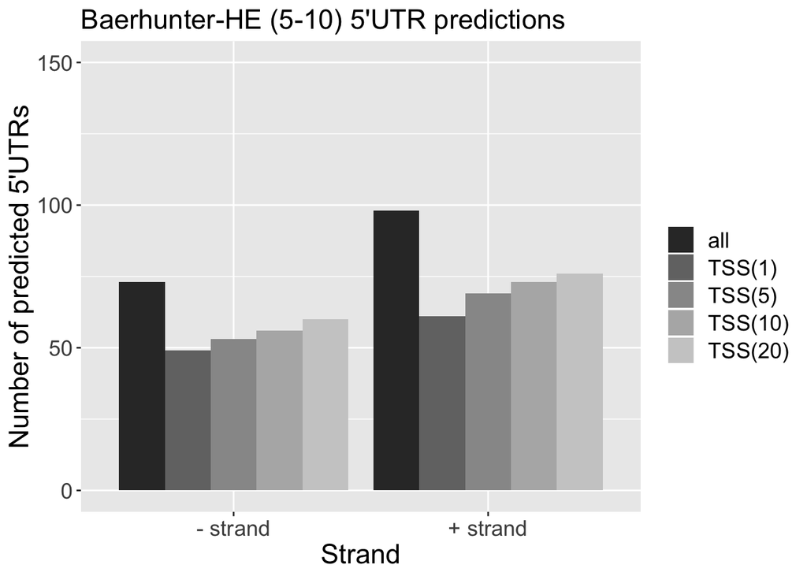

```r
#high expression only
v.y  <- c(tss_high5.10_5[5], tss_high5.10_1[9], tss_high5.10_5[9], tss_high5.10_10[9], tss_high5.10_20[9], tss_high5.10_5[6], tss_high5.10_1[10], tss_high5.10_5[10], tss_high5.10_10[10], tss_high5.10_20[10])
v.labels <- rep(c("all", "TSS(1)", "TSS(5)","TSS(10)", "TSS(20)"), 2)
v.strand <- c(rep("+ strand", 5), rep("- strand",5))
df <- data.frame(cbind(v.labels, v.strand, v.y))
colnames(df) <- c("labels", "strand", "num_pred_5pUTRs")
#put the v.types factor in the right order in the plot
df$labels <- factor(df$labels, levels=c('all', 'TSS(1)', 'TSS(5)', 'TSS(10)', 'TSS(20)'))
# df$v.y is factor and needs to be numeric
p <- ggplot(data=df, aes(x=strand, y=as.numeric(as.character(num_pred_5pUTRs)), fill=labels)) +
    geom_bar(stat="identity", position=position_dodge()) +
    scale_y_continuous(limits=c(0, 150)) +
    xlab("Strand") +
    ylab("Number of predicted 5'UTRs") +
    labs(fill='') +
    scale_fill_grey() +
    labs(title="Baerhunter-HE (5-10) 5'UTR predictions" ) +
    theme(plot.caption = element_text(hjust=0.5)) +
    theme(plot.title = element_text(size=17)) +
    theme(text = element_text(size = 17))
p
```

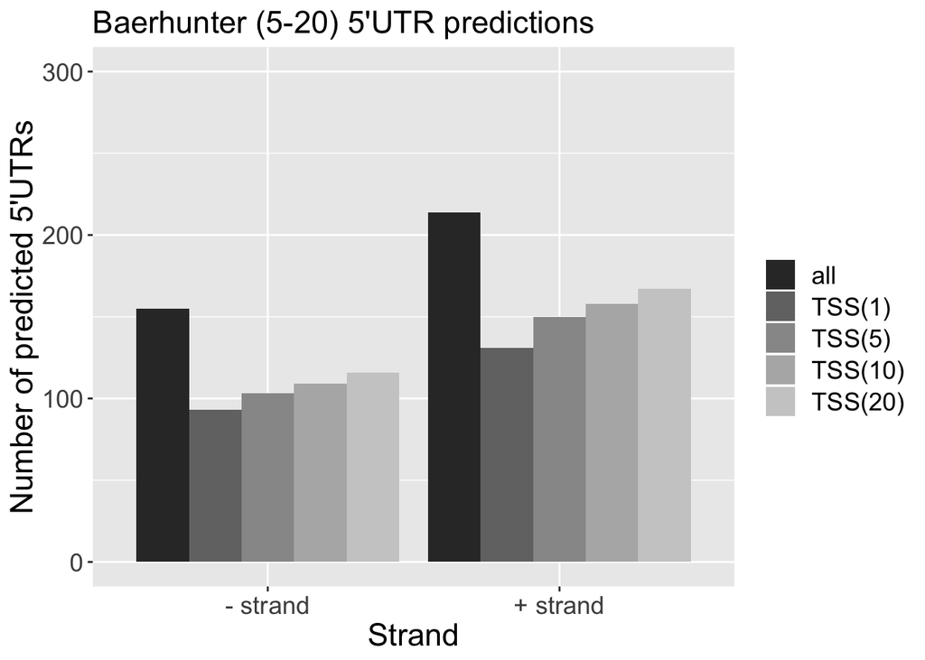

```r
# REPEAT FOR OTHER CUT-OFFS
# Cut-off 5-20
v.y  <- c(tss_5.20_5[5], tss_5.20_1[9], tss_5.20_5[9], tss_5.20_10[9], tss_5.20_20[9], tss_5.20_5[6], tss_5.20_1[10], tss_5.20_5[10], tss_5.20_10[10], tss_5.20_20[10])
v.labels <- rep(c("all", "TSS(1)", "TSS(5)","TSS(10)", "TSS(20)"), 2)
v.strand <- c(rep("+ strand", 5), rep("- strand",5))
df <- data.frame(cbind(v.labels, v.strand, v.y))
colnames(df) <- c("labels", "strand", "num_pred_5pUTRs")
#put the v.types factor in the right order in the plot
df$labels <- factor(df$labels, levels=c('all', 'TSS(1)', 'TSS(5)', 'TSS(10)', 'TSS(20)'))
# df$v.y is factor and needs to be numeric

p <- ggplot(data=df, aes(x=strand, y=as.numeric(as.character(num_pred_5pUTRs)), fill=labels)) +
    geom_bar(stat="identity", position=position_dodge()) +
    scale_y_continuous(limits=c(0, 300)) +
    xlab("Strand") +
    ylab("Number of predicted 5'UTRs") +
    labs(fill='') +
    scale_fill_grey() +
    labs(title="Baerhunter (5-20) 5'UTR predictions" ) +
    theme(plot.caption = element_text(hjust=0.5)) +
    theme(plot.title = element_text(size=17)) +
    theme(text = element_text(size = 17))
p
```

```r
tiff(filename="output/real_data/SuppFig7A.tiff")
p
dev.off()
```

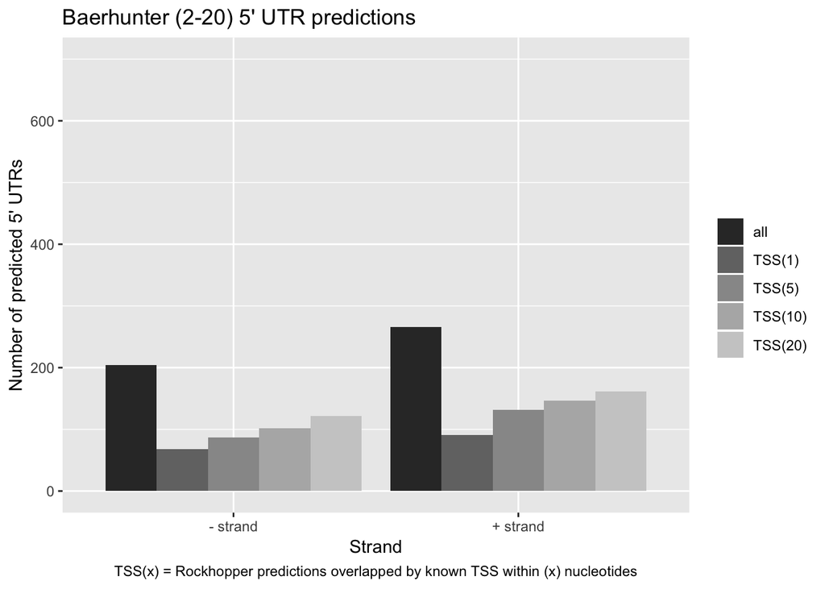

```r
# Cut-off 2-20
v.y  <- c(tss_2.20_5[5], tss_2.20_1[9], tss_2.20_5[9], tss_2.20_10[9], tss_2.20_20[9], tss_2.20_5[6], tss_2.20_1[10], tss_2.20_5[10], tss_2.20_10[10], tss_2.20_20[10])
v.labels <- rep(c("all", "TSS(1)", "TSS(5)","TSS(10)", "TSS(20)"), 2)
v.strand <- c(rep("+ strand", 5), rep("- strand",5))
df <- data.frame(cbind(v.labels, v.strand, v.y))
colnames(df) <- c("labels", "strand", "num_pred_5pUTRs")
#put the v.types factor in the right order in the plot
df$labels <- factor(df$labels, levels=c('all', 'TSS(1)', 'TSS(5)', 'TSS(10)', 'TSS(20)'))
# df$v.y is factor and needs to be numeric
p <- ggplot(data=df, aes(x=strand, y=as.numeric(as.character(num_pred_5pUTRs)), fill=labels)) +
    geom_bar(stat="identity", position=position_dodge()) +
    scale_y_continuous(limits=c(0, 700)) +
    xlab("Strand") +
    ylab("Number of predicted 5' UTRs") +
    labs(fill='') +
    scale_fill_grey() +
    labs(title="Baerhunter (2-20) 5' UTR predictions", caption="TSS(x) = Rockhopper predictions overlapped by known TSS within (x) nucleotides") +
    theme(plot.caption = element_text(hjust=0.5))

p
```

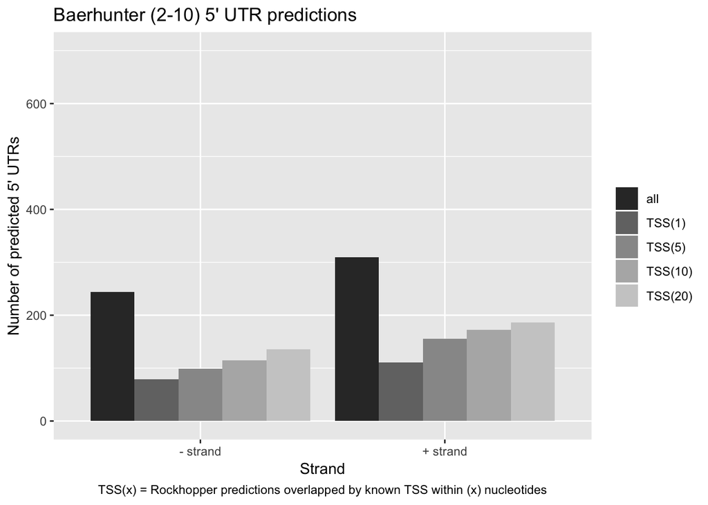

```r
# Cut-off 2-10
v.y  <- c(tss_2.10_5[5], tss_2.10_1[9], tss_2.10_5[9], tss_2.10_10[9], tss_2.10_20[9], tss_2.10_5[6], tss_2.10_1[10], tss_2.10_5[10], tss_2.10_10[10], tss_2.10_20[10])
v.labels <- rep(c("all", "TSS(1)", "TSS(5)","TSS(10)", "TSS(20)"), 2)
v.strand <- c(rep("+ strand", 5), rep("- strand",5))
df <- data.frame(cbind(v.labels, v.strand, v.y))
colnames(df) <- c("labels", "strand", "num_pred_5pUTRs")
#put the v.types factor in the right order in the plot
df$labels <- factor(df$labels, levels=c('all', 'TSS(1)', 'TSS(5)', 'TSS(10)', 'TSS(20)'))
# df$v.y is factor and needs to be numeric
p <- ggplot(data=df, aes(x=strand, y=as.numeric(as.character(num_pred_5pUTRs)), fill=labels)) +
    geom_bar(stat="identity", position=position_dodge()) +
    scale_y_continuous(limits=c(0, 700)) +
    xlab("Strand") +
    ylab("Number of predicted 5' UTRs") +
    labs(fill='') +
    scale_fill_grey() +
    labs(title="Baerhunter (2-10) 5' UTR predictions", caption="TSS(x) = Rockhopper predictions overlapped by known TSS within (x) nucleotides") +
    theme(plot.caption = element_text(hjust=0.5))

p
```

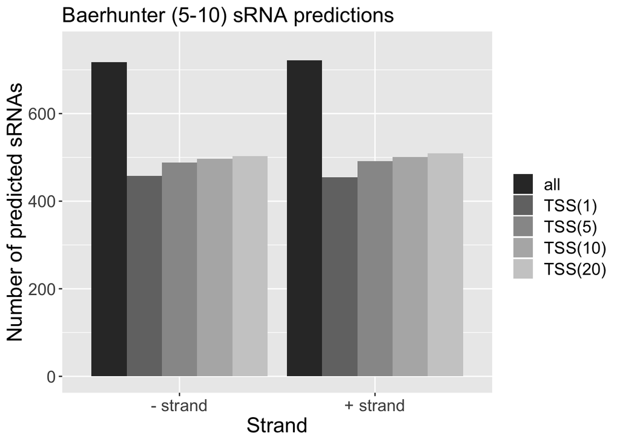

```r
# END REPEAT

# Make barplots of predictions for sRNA (backed up by TSS)

v.y  <- c(tss_5.10_5[1], tss_5.10_1[7], tss_5.10_5[7], tss_5.10_10[7], tss_5.10_20[7], tss_5.10_5[2], tss_5.10_1[8], tss_5.10_5[8], tss_5.10_10[8], tss_5.10_20[8])
v.types <- rep(c("all", "TSS(1)", "TSS(5)","TSS(10)", "TSS(20)"), 2)
v.group <- c(rep("+ strand", 5), rep("- strand",5))
df <- data.frame(cbind(v.types, v.group, v.y))
colnames(df) <- c("labels", "strand", "num_pred_sRNAs")
#put the v.types factor in the right order in the plot
df$labels <- factor(df$labels, levels=c('all', 'TSS(1)', 'TSS(5)', 'TSS(10)', 'TSS(20)'))
# df$v.y is factor and needs to be numeric
p <- ggplot(data=df, aes(x=strand, y=as.numeric(as.character(num_pred_sRNAs)), fill=labels)) +
    geom_bar(stat="identity", position=position_dodge()) +
    scale_y_continuous(limits=c(0, 750)) +
    xlab("Strand") +
    ylab("Number of predicted sRNAs") +
    labs(fill='') +
    scale_fill_grey() +
    labs(title="Baerhunter (5-10) sRNA predictions" ) +
    theme(plot.caption = element_text(hjust=0.5)) +
    theme(plot.title = element_text(size=17)) +
    theme(text = element_text(size = 17))
p
```

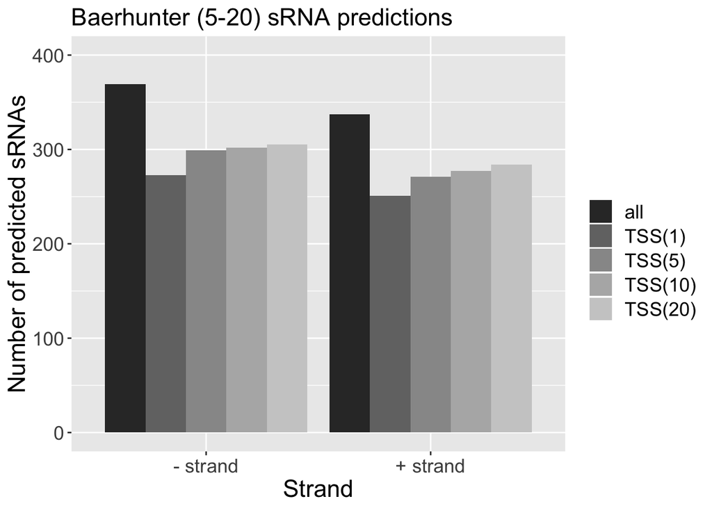

```r
# REPEAT FOR OTHER CUT-OFFS
#Cut-off 5-20
v.y  <- c(tss_5.20_5[1], tss_5.20_1[7], tss_5.20_5[7], tss_5.20_10[7], tss_5.20_20[7], tss_5.20_5[2], tss_5.20_1[8], tss_5.20_5[8], tss_5.20_10[8], tss_5.20_20[8])
v.types <- rep(c("all", "TSS(1)", "TSS(5)","TSS(10)", "TSS(20)"), 2)
v.group <- c(rep("+ strand", 5), rep("- strand",5))
df <- data.frame(cbind(v.types, v.group, v.y))
colnames(df) <- c("labels", "strand", "num_pred_sRNAs")
#put the v.types factor in the right order in the plot
df$labels <- factor(df$labels, levels=c('all', 'TSS(1)', 'TSS(5)', 'TSS(10)', 'TSS(20)'))
# df$v.y is factor and needs to be numeric
p <- ggplot(data=df, aes(x=strand, y=as.numeric(as.character(num_pred_sRNAs)), fill=labels)) +
    geom_bar(stat="identity", position=position_dodge()) +
    scale_y_continuous(limits=c(0, 400)) +
    xlab("Strand") +
    ylab("Number of predicted sRNAs") +
    labs(fill='') +
    scale_fill_grey() +
    labs(title="Baerhunter (5-20) sRNA predictions" ) +
    theme(plot.caption = element_text(hjust=0.5)) +
    theme(plot.title = element_text(size=17)) +
    theme(text = element_text(size = 17))
p
```

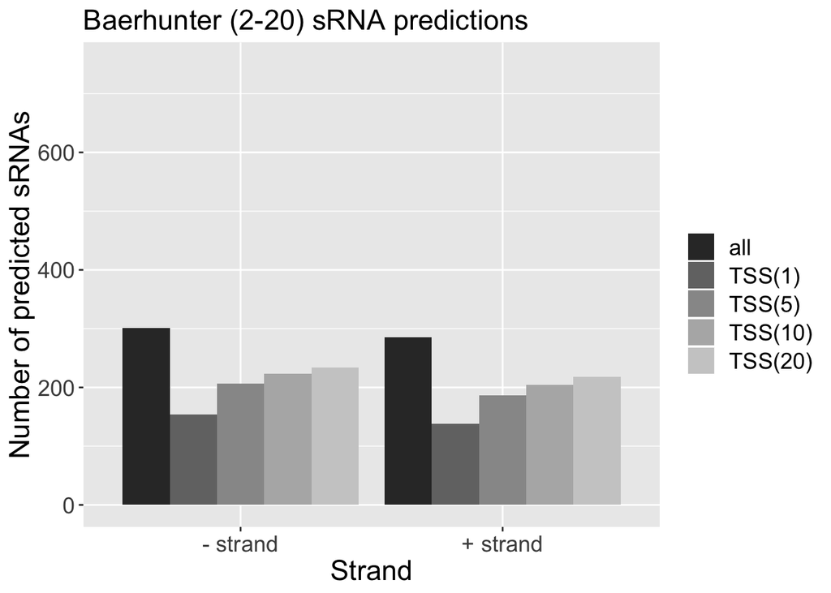

```r
# Cut-off 2-20
v.y  <- c(tss_2.20_5[1], tss_2.20_1[7], tss_2.20_5[7], tss_2.20_10[7], tss_2.20_20[7], tss_2.20_5[2], tss_2.20_1[8], tss_2.20_5[8], tss_2.20_10[8], tss_2.20_20[8])
v.types <- rep(c("all", "TSS(1)", "TSS(5)","TSS(10)", "TSS(20)"), 2)
v.group <- c(rep("+ strand", 5), rep("- strand",5))
df <- data.frame(cbind(v.types, v.group, v.y))
colnames(df) <- c("labels", "strand", "num_pred_sRNAs")
#put the v.types factor in the right order in the plot
df$labels <- factor(df$labels, levels=c('all', 'TSS(1)', 'TSS(5)', 'TSS(10)', 'TSS(20)'))
# df$v.y is factor and needs to be numeric
p <- ggplot(data=df, aes(x=strand, y=as.numeric(as.character(num_pred_sRNAs)), fill=labels)) +
    geom_bar(stat="identity", position=position_dodge()) +
    scale_y_continuous(limits=c(0, 750)) +
    xlab("Strand") +
    ylab("Number of predicted sRNAs") +
    labs(fill='') +
    scale_fill_grey() +
    labs(title="Baerhunter (2-20) sRNA predictions" ) +
    theme(plot.caption = element_text(hjust=0.5)) +
    theme(plot.title = element_text(size=17)) +
    theme(text = element_text(size = 17))
p
```

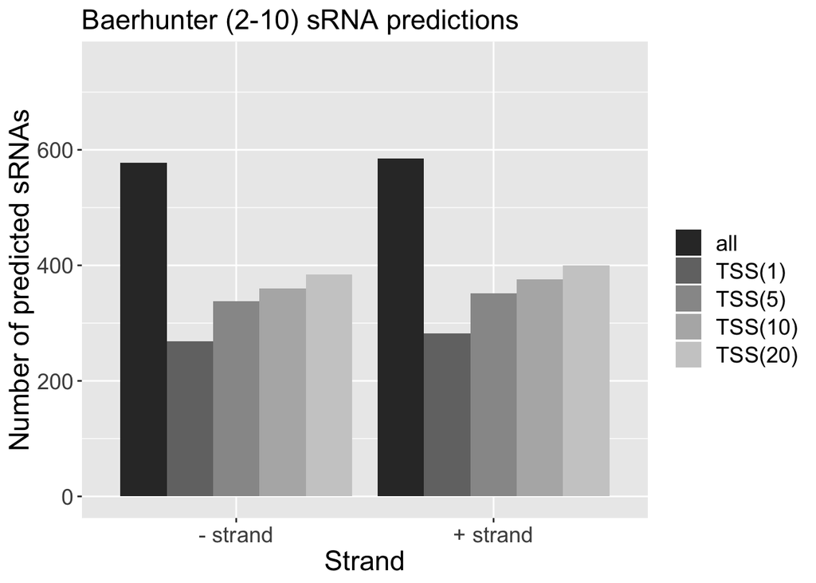

```r
# Cut-off 2-10
v.y  <- c(tss_2.10_5[1], tss_2.10_1[7], tss_2.10_5[7], tss_2.10_10[7], tss_2.10_20[7], tss_2.10_5[2], tss_2.10_1[8], tss_2.10_5[8], tss_2.10_10[8], tss_2.10_20[8])
v.types <- rep(c("all", "TSS(1)", "TSS(5)","TSS(10)", "TSS(20)"), 2)
v.group <- c(rep("+ strand", 5), rep("- strand",5))
df <- data.frame(cbind(v.types, v.group, v.y))
colnames(df) <- c("labels", "strand", "num_pred_sRNAs")
#put the v.types factor in the right order in the plot
df$labels <- factor(df$labels, levels=c('all', 'TSS(1)', 'TSS(5)', 'TSS(10)', 'TSS(20)'))
# df$v.y is factor and needs to be numeric
p <- ggplot(data=df, aes(x=strand, y=as.numeric(as.character(num_pred_sRNAs)), fill=labels)) +
    geom_bar(stat="identity", position=position_dodge()) +
    scale_y_continuous(limits=c(0, 750)) +
    xlab("Strand") +
    ylab("Number of predicted sRNAs") +
    labs(fill='') +
    scale_fill_grey() +
    labs(title="Baerhunter (2-10) sRNA predictions" ) +
    theme(plot.caption = element_text(hjust=0.5)) +
    theme(plot.title = element_text(size=17)) +
    theme(text = element_text(size = 17))
p
```

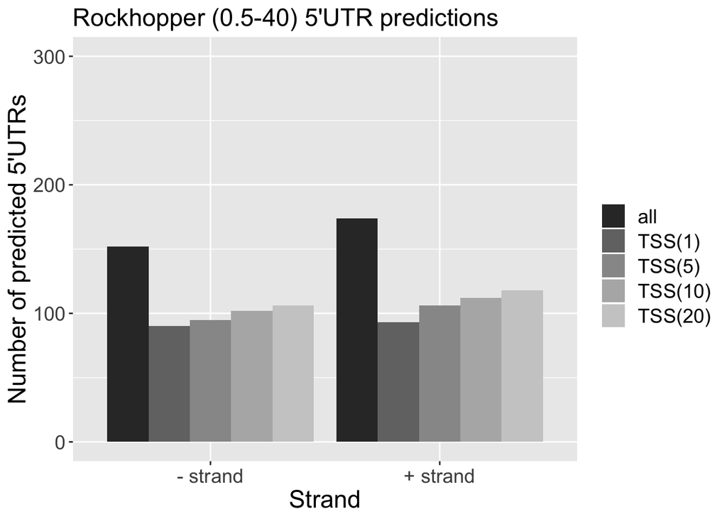

```r
# END REPEAT


# Checking results from Rockhopper against known TSS #
# 5' UTR predictions
# Using parameters 0.5/40
tss_05.40_1 <- compare_TSS_with_predicted("output/real_data/rockhopper_bam_0.5_40_output/NC_999999.gff3", tss.gr, maxgap=1L)

tss_05.40_5 <- compare_TSS_with_predicted("output/real_data/rockhopper_bam_0.5_40_output/NC_999999.gff3", tss.gr, maxgap=5L)

tss_05.40_10 <- compare_TSS_with_predicted("output/real_data/rockhopper_bam_0.5_40_output/NC_999999.gff3", tss.gr, maxgap=10L)

tss_05.40_20 <- compare_TSS_with_predicted("output/real_data/rockhopper_bam_0.5_40_output/NC_999999.gff3", tss.gr, maxgap=20L)

v.y  <- c(tss_05.40_5[5], tss_05.40_1[9], tss_05.40_5[9], tss_05.40_10[9], tss_05.40_20[9], tss_05.40_5[6], tss_05.40_1[10], tss_05.40_5[10], tss_05.40_10[10], tss_05.40_20[10])
v.labels <- rep(c("all", "TSS(1)", "TSS(5)","TSS(10)", "TSS(20)"), 2)
v.strand <- c(rep("+ strand", 5), rep("- strand",5))
df.rh <- data.frame(cbind(v.labels, v.strand, v.y))
colnames(df.rh) <- c("labels", "strand", "num_pred_5pUTRs")
#put the v.types factor in the right order in the plot
df.rh$labels <- factor(df.rh$labels, levels=c('all', 'TSS(1)', 'TSS(5)', 'TSS(10)', 'TSS(20)'))
# df$v.y is factor and needs to be numeric
p <- ggplot(data=df.rh, aes(x=strand, y=as.numeric(as.character(num_pred_5pUTRs)), fill=labels)) +
    geom_bar(stat="identity", position=position_dodge()) +
    scale_y_continuous(limits=c(0, 300)) +
    xlab("Strand") +
    ylab("Number of predicted 5'UTRs") +
    labs(fill='') +
    scale_fill_grey() +
    labs(title="Rockhopper (0.5-40) 5'UTR predictions" ) +
    theme(plot.caption = element_text(hjust=0.5)) +
    theme(plot.title = element_text(size=17)) +
    theme(text = element_text(size = 17))
p
```

```r
tiff(filename="output/real_data/SuppFig7C.tiff")
p
dev.off()
```

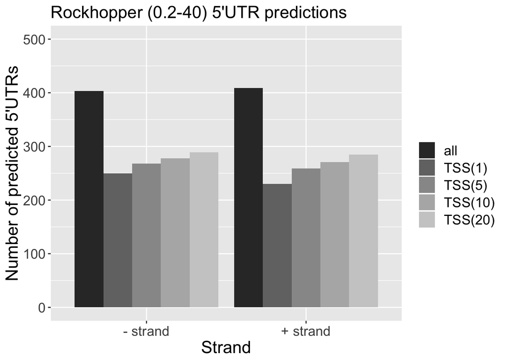

```r
# Using parameters 0.2/40
tss_02.40_1 <- compare_TSS_with_predicted("output/real_data/rockhopper_bam_0.2_40_output/NC_999999.gff3", tss.gr, maxgap=1L)

tss_02.40_5 <- compare_TSS_with_predicted("output/real_data/rockhopper_bam_0.2_40_output/NC_999999.gff3", tss.gr, maxgap=5L)

tss_02.40_10 <- compare_TSS_with_predicted("output/real_data/rockhopper_bam_0.2_40_output/NC_999999.gff3", tss.gr, maxgap=10L)

tss_02.40_20 <- compare_TSS_with_predicted("output/real_data/rockhopper_bam_0.2_40_output/NC_999999.gff3", tss.gr, maxgap=20L)

v.y  <- c(tss_02.40_5[5], tss_02.40_1[9], tss_02.40_5[9], tss_02.40_10[9], tss_02.40_20[9], tss_02.40_5[6], tss_02.40_1[10], tss_02.40_5[10], tss_02.40_10[10], tss_02.40_20[10])
v.labels <- rep(c("all", "TSS(1)", "TSS(5)","TSS(10)", "TSS(20)"), 2)
v.strand <- c(rep("+ strand", 5), rep("- strand",5))
df.rh <- data.frame(cbind(v.labels, v.strand, v.y))
colnames(df.rh) <- c("labels", "strand", "num_pred_5pUTRs")
#put the v.types factor in the right order in the plot
df.rh$labels <- factor(df.rh$labels, levels=c('all', 'TSS(1)', 'TSS(5)', 'TSS(10)', 'TSS(20)'))
# df$v.y is factor and needs to be numeric
p <- ggplot(data=df.rh, aes(x=strand, y=as.numeric(as.character(num_pred_5pUTRs)), fill=labels)) +
    geom_bar(stat="identity", position=position_dodge()) +
    scale_y_continuous(limits=c(0, 500)) +
    xlab("Strand") +
    ylab("Number of predicted 5'UTRs") +
    labs(fill='') +
    scale_fill_grey() +
    labs(title="Rockhopper (0.2-40) 5'UTR predictions" ) +
    theme(plot.caption = element_text(hjust=0.5)) +
    theme(plot.title = element_text(size=17)) +
    theme(text = element_text(size = 17))
p
```

```r
tiff(filename="output/real_data/SuppFig7D.tiff")
p
dev.off()
```

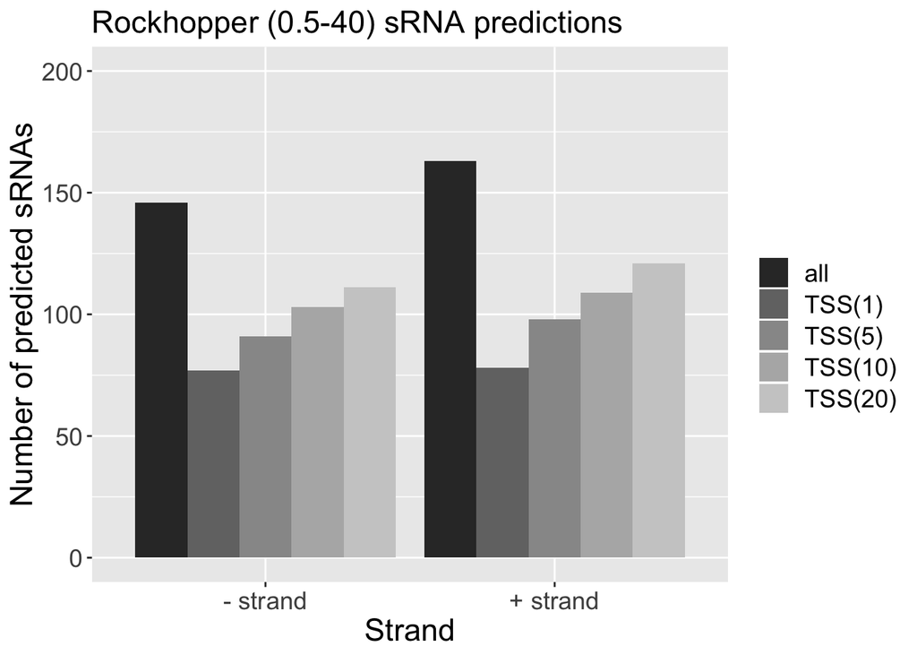

```r
# Rockhopper sRNA predictions #
# Cut-off 0.5/40
v.y  <- c(tss_05.40_5[1], tss_05.40_1[7], tss_05.40_5[7], tss_05.40_10[7], tss_05.40_20[7], tss_05.40_5[2], tss_05.40_1[8], tss_05.40_5[8], tss_05.40_10[8], tss_05.40_20[8])
v.types <- rep(c("all", "TSS(1)", "TSS(5)","TSS(10)", "TSS(20)"), 2)
v.group <- c(rep("+ strand", 5), rep("- strand",5))
df.rh <- data.frame(cbind(v.types, v.group, v.y))
colnames(df.rh) <- c("labels", "strand", "num_pred_sRNAs")
#put the v.types factor in the right order in the plot
df.rh$labels <- factor(df.rh$labels, levels=c('all', 'TSS(1)', 'TSS(5)', 'TSS(10)', 'TSS(20)'))
# df$v.y is factor and needs to be numeric
p <- ggplot(data=df.rh, aes(x=strand, y=as.numeric(as.character(num_pred_sRNAs)), fill=labels)) +
    geom_bar(stat="identity", position=position_dodge()) +
    scale_y_continuous(limits=c(0, 200)) +
    xlab("Strand") +
    ylab("Number of predicted sRNAs") +
    labs(fill='') +
    scale_fill_grey() +
    labs(title="Rockhopper (0.5-40) sRNA predictions" ) +
    theme(plot.caption = element_text(hjust=0.5)) +
    theme(plot.title = element_text(size=17)) +
    theme(text = element_text(size = 17))
p
```

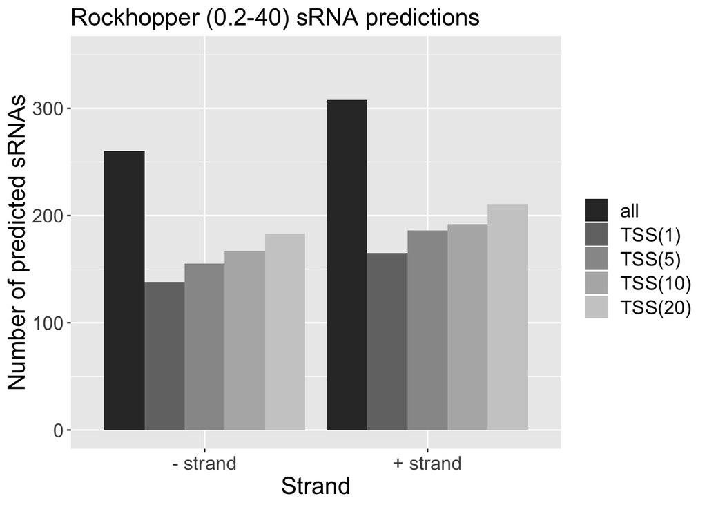

```r
# Cut-off 0.2/40
v.y  <- c(tss_02.40_5[1], tss_02.40_1[7], tss_02.40_5[7], tss_02.40_10[7], tss_02.40_20[7], tss_02.40_5[2], tss_02.40_1[8], tss_02.40_5[8], tss_02.40_10[8], tss_02.40_20[8])
v.types <- rep(c("all", "TSS(1)", "TSS(5)","TSS(10)", "TSS(20)"), 2)
v.group <- c(rep("+ strand", 5), rep("- strand",5))
df.rh <- data.frame(cbind(v.types, v.group, v.y))
colnames(df.rh) <- c("labels", "strand", "num_pred_sRNAs")
#put the v.types factor in the right order in the plot
df.rh$labels <- factor(df.rh$labels, levels=c('all', 'TSS(1)', 'TSS(5)', 'TSS(10)', 'TSS(20)'))
# df$v.y is factor and needs to be numeric
p <- ggplot(data=df.rh, aes(x=strand, y=as.numeric(as.character(num_pred_sRNAs)), fill=labels)) +
    geom_bar(stat="identity", position=position_dodge()) +
    scale_y_continuous(limits=c(0, 350)) +
    xlab("Strand") +
    ylab("Number of predicted sRNAs") +
    labs(fill='') +
    scale_fill_grey() +
    labs(title="Rockhopper (0.2-40) sRNA predictions" ) +
    theme(plot.caption = element_text(hjust=0.5)) +
    theme(plot.title = element_text(size=17)) +
    theme(text = element_text(size = 17))
p
```

```r
# Create a table holding all the results for predictions as matched by TSS data

create_TSS_results_vector <- function(v1, v5, v10, v20)  {
  res.v <- c(v1[1]+v1[2], v1[7]+v1[8], v5[7]+v5[8], v10[7]+v10[8], v20[7]+v20[8],
             v1[5]+v1[6], v1[9]+v1[10], v5[9]+v5[10], v10[9]+v10[10], v20[9]+v20[10])
  names(res.v) <- c("num_pred_sRNA", "sRNA_TSS.1", "sRNA_TSS.5", "sRNA_TSS.10", "sRNA_TSS.20", "num_pred_5pUTR", "UTR_TSS.1", "UTR_TSS.5", "UTR_TSS.10", "UTR_TSS.20" )
  return(res.v)
}

v.5_10 <- create_TSS_results_vector(tss_5.10_1, tss_5.10_5, tss_5.10_10, tss_5.10_20)

v.5_20 <- create_TSS_results_vector(tss_5.20_1, tss_5.20_5, tss_5.20_10, tss_5.20_20)

v.2_10 <- create_TSS_results_vector(tss_2.10_1, tss_2.10_5, tss_2.10_10, tss_2.10_20)

v.2_20 <- create_TSS_results_vector(tss_2.20_1, tss_2.20_5, tss_2.20_10, tss_2.20_20)

v.h.5_10 <- create_TSS_results_vector(tss_high5.10_1, tss_high5.10_5, tss_high5.10_10, tss_high5.10_20)

v.rh.02.40 <- create_TSS_results_vector(tss_02.40_1, tss_02.40_5, tss_02.40_10, tss_02.40_20)

v.rh.05.40 <- create_TSS_results_vector(tss_05.40_1, tss_05.40_5, tss_05.40_10, tss_05.40_20)

m.TSS.res <- rbind(v.5_10, v.5_20, v.2_10, v.2_20, v.h.5_10, v.rh.02.40, v.rh.05.40)
colnames(m.TSS.res) <- c("num_pred_sRNA", "sRNA_TSS.1", "sRNA_TSS.5", "sRNA_TSS.10", "sRNA_TSS.20", "num_pred_UTR", "UTR_TSS.1", "UTR_TSS.5", "UTR_TSS.10", "UTR_TSS.20")
rownames(m.TSS.res) <- c("bh_5-10", "bh_5-20", "bh_2-10", "bh_2-20", "bh_he_5-10", "rh_0.2-40", "rh_0.5-40")

# Print out in a table the results of predicting sRNAs and UTRs and how they match the TSS values from the Cortes et al. supplementary tables.
m.TSS.res
```

```
##            num_pred_sRNA sRNA_TSS.1 sRNA_TSS.5 sRNA_TSS.10 sRNA_TSS.20
## bh_5-10             1439        913        979         998        1012
## bh_5-20              706        524        570         579         589
## bh_2-10             1163        551        690         736         784
## bh_2-20              586        292        393         427         452
## bh_he_5-10           235        192        209         212         214
## rh_0.2-40            568        303        341         359         393
## rh_0.5-40            309        155        189         212         232
##            num_pred_UTR UTR_TSS.1 UTR_TSS.5 UTR_TSS.10 UTR_TSS.20
## bh_5-10             431       249       279        294        312
## bh_5-20             369       224       253        267        283
## bh_2-10             554       190       254        287        322
## bh_2-20             470       159       219        248        283
## bh_he_5-10          171       110       122        129        136
## rh_0.2-40           812       480       527        549        574
## rh_0.5-40           326       183       201        214        224
```

## Example of downstream analysis - differential gene expression with DESeq2

In this example, we create a counts file that contains counts for both coding genes and ncRNA elements and use DESeq2 to identify differentially expressed features. We separate the UTRs from the CDS regions, as it is not uncommon to see differential expression in the UTR without much signal covering the CDS region. In the dataset used here, we have 3 samples from exponentially growing Mtb and 3 samples grown in starved condition. We do not consider any other covariates. Following differential expression analysis with DESeq2, we print out the 10 top “gene” features (ordered by adjusted p-value), followed by the top 10 ncRNA features.

```r
# Create a counts file with counts from genes and ncRNA
system("( cat output/real_data/mtb_5_10/gene_Counts.csv ; tail -n +2 output/real_data/mtb_5_10/putative_UTR_Counts.csv; tail -n +2 output/real_data/mtb_5_10/putative_sRNA_Counts.csv; ) | cat > output/real_data/mtb_5_10/allCounts.csv")

#Call differential_expression() function
de.res <- differential_expression(feature_count_file="output/real_data/mtb_5_10/allCounts.csv", metadata_file="output/real_data/conditions.txt", cutoff_value=10, multiple_variables=FALSE, main_condition="condition", output_file_name="output/real_data/mtb_5_10/allCounts_diff_expression.csv")
summary(de.res)
```

```
##       Length        Class         Mode
##            6 DESeqResults           S4
```

```r
resOrdered <- de.res[order(de.res$padj),]
resOrdered[grep('gene', rownames(resOrdered))[1:10],]
```

```
## log2 fold change (MLE): condition sta vs exp
## Wald test p-value: condition sta vs exp
## DataFrame with 10 rows and 6 columns
##                      baseMean    log2FoldChange             lfcSE
##                     <numeric>         <numeric>         <numeric>
## gene:Rv3290c 6946.16101843998  4.59212752200441   0.1115921706473
## gene:Rv3289c 911.477944803568  5.54113985615305 0.167151207655758
## gene:Rv1217c 953.241067781054 -4.60466648965562 0.156527807161985
## gene:Rv1221  1733.05591995766  3.49214598988944 0.132611449173743
## gene:Rv1216c  792.18964241329 -4.17083934159263 0.158729960557531
## gene:Rv0188  698.871159380172  3.74245474016782 0.143663339041622
## gene:Rv2988c 615.877705623064 -5.40224085177584 0.207558941076515
## gene:Rv2940c  2368.0632594404 -2.87387051202139 0.111122757512493
## gene:Rv1218c 836.704984073711 -4.28036852413017 0.168704739441202
## gene:Rv1646  988.692390385132   3.1762818405429 0.128641744207473
##                           stat                pvalue                  padj
##                      <numeric>             <numeric>             <numeric>
## gene:Rv3290c  41.1509830426937                     0                     0
## gene:Rv3289c  33.1504625893271 5.57708673028236e-241 1.56967106023797e-237
## gene:Rv1217c -29.4175621133594 3.27445648871276e-190 4.60797889374103e-187
## gene:Rv1221   26.3336688622877  7.8962251649677e-153  7.4079752422672e-150
## gene:Rv1216c  -26.276320657693 3.57697623712251e-152  2.8763998912518e-149
## gene:Rv0188   26.0501723343877 1.33931138026375e-149 9.42372969938083e-147
## gene:Rv2988c -26.0275024711383 2.41891849565159e-149  1.5128991346692e-146
## gene:Rv2940c  -25.862123802123 1.77752951121718e-147 1.00057136186415e-144
## gene:Rv1218c -25.3719518391005  5.1455385552957e-142  2.6331124116145e-139
## gene:Rv1646   24.6909108712037 1.33910630116396e-134 5.87134331565691e-132
```

```r
resOrdered[grep('putative', rownames(resOrdered))[1:10],]
```

```
## log2 fold change (MLE): condition sta vs exp
## Wald test p-value: condition sta vs exp
## DataFrame with 10 rows and 6 columns
##                                        baseMean    log2FoldChange
##                                       <numeric>         <numeric>
## putative_UTR:p3671812_3672327  1436.85034055422  5.26166812773426
## putative_sRNA:p2980909_2981341 897.776236412009  4.39834067657727
## putative_UTR:p1855652_1855763  851.000088345422  2.87794473810418
## putative_UTR:p219918_220410      306.4696874016  4.28088457026081
## putative_sRNA:m1271537_1272172 8820.73092013339  2.94855246662975
## putative_UTR:p4314724_4315829  1315.78958104592 -3.33841423967345
## putative_UTR:p987050_987232     433.53636921732  3.18570373906372
## putative_sRNA:p1113860_1114259 558.578795062758  3.19722681614288
## putative_UTR:p1197116_1197230  6250.41098353743  2.66015881676866
## putative_UTR:p2052689_2052932  271.240520328354  4.10590443857957
##                                            lfcSE              stat
##                                        <numeric>         <numeric>
## putative_UTR:p3671812_3672327    0.1651533278156   31.859292194276
## putative_sRNA:p2980909_2981341 0.152498077261618  28.8419418497434
## putative_UTR:p1855652_1855763   0.12398890384654  23.2113088253946
## putative_UTR:p219918_220410    0.189028920246203  22.6467175746711
## putative_sRNA:m1271537_1272172 0.132241750610363  22.2966835588661
## putative_UTR:p4314724_4315829  0.156355913759452 -21.3513781436465
## putative_UTR:p987050_987232    0.151280370724483  21.0582755965454
## putative_sRNA:p1113860_1114259 0.154843733349527  20.6480866030647
## putative_UTR:p1197116_1197230  0.132357855855588  20.0982314164343
## putative_UTR:p2052689_2052932  0.214889542894979  19.1070462678876
##                                               pvalue                  padj
##                                            <numeric>             <numeric>
## putative_UTR:p3671812_3672327  9.78766524125277e-223 1.83649225476706e-219
## putative_sRNA:p2980909_2981341 6.39455376609544e-183 7.19898862987024e-180
## putative_UTR:p1855652_1855763  3.50054562097241e-119 1.15909242943845e-116
## putative_UTR:p219918_220410    1.50299592122244e-113 4.45282317924269e-111
## putative_sRNA:m1271537_1272172  3.9791991702291e-110 1.06661486329617e-107
## putative_UTR:p4314724_4315829  3.78607848696503e-101  8.52473432125046e-99
## putative_UTR:p987050_987232     1.92038583387441e-98  3.62115221129863e-96
## putative_sRNA:p1113860_1114259  1.01563356409702e-94  1.78656291634442e-92
## putative_UTR:p1197116_1197230    7.6470631836119e-90  1.16338699082571e-87
## putative_UTR:p2052689_2052932   2.20607481293426e-81  2.69956415695804e-79
```